# `Concrete Strength Prediction`

## `Domain:`

Civil engineering

## `Data:`

https://archive.ics.uci.edu/ml/datasets/Concrete+Compressive+Strength

## `Description:`

Concrete is the most important material in civil engineering. The concrete compressive strength is a highly nonlinear function of age and ingredients. These ingredients include cement, blast furnace slag, fly ash, water, superplasticizer, coarse aggregate, and fine aggregate.

## `Attributes Information:`

|  | **Name** | **Data Type** | **Measurement** | **Description** |
| --- | --- | --- | --- | --- |
| 1. | Cement (cement) | quantitative | kg in a m3 mixture | Input Variable |
| 2. | Blast Furnace Slag (slag) | quantitative | kg in a m3 mixture | Input Variable |
| 3. | Fly Ash (ash) | quantitative | kg in a m3 mixture | Input Variable |
| 4. | Water(water) | quantitative | kg in a m3 mixture | Input Variable |
| 5. | Superplasticizer (superplastic) | quantitative | kg in a m3 mixture | Input Variable |
| 6. | Coarse Aggregate (coarseagg) | quantitative | kg in a m3 mixture | Input Variable |
| 7. | Fine Aggregate (fineagg) | quantitative | kg in a m3 mixture | Input Variable |
| 8. | Age(age) | quantitative | Day (1~365) | Input Variable |
| 9. | Concrete compressive strength(strength) | quantitative | MPa | Output Variable |

## `Objective:`

Is to predict the compressive strength of concrete. Apply feature engineering and model tuning to obtain a score above **85%**.

## `Steps and tasks`

1. Libraries & Dataset Import
2. EDA
1. Univariate Analysis
2. Bivariate Analysis
3. Feature Engineering
1. Dealing with the Outliers
2. Slag, Ash, Superplastic - Binarization
3. Age vs Strength
4. Age - Binning
5. Water Cement Ratio (w/c)
6. Polynomial Features, PCA, Scaling and Transformations
7. Summary
3. Hyperparameters Tunning
1. Collecting metrics on the best models
2. Summary
4. Conclusions

## Libraries & Dataset Import

```python
# Basic imports
import pandas as pd
import numpy as np

# Plots
import matplotlib.pyplot as plt
%matplotlib inline
import seaborn as sns

import warnings
warnings.filterwarnings('ignore')

from IPython.core.display import display

# round to 4 decimal places in python pandas
pd.options.display.float_format = '{:.4f}'.format
```

```python
df = pd.read_csv('concrete.csv')
df.head()
```

|  | cement | slag | ash | water | superplastic | coarseagg | fineagg | age | strength |
| --- | --- | --- | --- | --- | --- | --- | --- | --- | --- |
| 0 | 141.3000 | 212.0000 | 0.0000 | 203.5000 | 0.0000 | 971.8000 | 748.5000 | 28 | 29.8900 |
| 1 | 168.9000 | 42.2000 | 124.3000 | 158.3000 | 10.8000 | 1080.8000 | 796.2000 | 14 | 23.5100 |
| 2 | 250.0000 | 0.0000 | 95.7000 | 187.4000 | 5.5000 | 956.9000 | 861.2000 | 28 | 29.2200 |
| 3 | 266.0000 | 114.0000 | 0.0000 | 228.0000 | 0.0000 | 932.0000 | 670.0000 | 28 | 45.8500 |
| 4 | 154.8000 | 183.4000 | 0.0000 | 193.3000 | 9.1000 | 1047.4000 | 696.7000 | 28 | 18.2900 |

```python
df.shape
```

```
(1030, 9)
```

## 2. EDA

### Univariate Analysis

- **Check for duplicates**

```python
duplicate_count = df.duplicated(keep='first').sum()
print('Total duplicates: ', duplicate_count)
```

```
Total duplicates:  25
```

**Insights:**

- There are **25 duplicates** which bring no additional information, but influence some statistical metrics, we want to removed them before any further analysis.

**Applying feature.**

```python
cdf = df.drop_duplicates(inplace=False, keep='first')
```

```python
cdf.info()
```

```
<class 'pandas.core.frame.DataFrame'>
Int64Index: 1005 entries, 0 to 1029
Data columns (total 9 columns):
 #   Column        Non-Null Count  Dtype
---  ------        --------------  -----
 0   cement        1005 non-null   float64
 1   slag          1005 non-null   float64
 2   ash           1005 non-null   float64
 3   water         1005 non-null   float64
 4   superplastic  1005 non-null   float64
 5   coarseagg     1005 non-null   float64
 6   fineagg       1005 non-null   float64
 7   age           1005 non-null   int64
 8   strength      1005 non-null   float64
dtypes: float64(8), int64(1)
memory usage: 78.5 KB
```

**Insights:**

- There are 1005 entries in the dataset after duplicates removal.
- There are no NULL values.

```python
cdf.describe().T
```

|  | count | mean | std | min | 25% | 50% | 75% | max |
| --- | --- | --- | --- | --- | --- | --- | --- | --- |
| cement | 1005.0000 | 278.6313 | 104.3443 | 102.0000 | 190.7000 | 265.0000 | 349.0000 | 540.0000 |
| slag | 1005.0000 | 72.0435 | 86.1708 | 0.0000 | 0.0000 | 20.0000 | 142.5000 | 359.4000 |
| ash | 1005.0000 | 55.5363 | 64.2080 | 0.0000 | 0.0000 | 0.0000 | 118.3000 | 200.1000 |
| water | 1005.0000 | 182.0753 | 21.3393 | 121.8000 | 166.6000 | 185.7000 | 192.9000 | 247.0000 |
| superplastic | 1005.0000 | 6.0332 | 5.9200 | 0.0000 | 0.0000 | 6.1000 | 10.0000 | 32.2000 |
| coarseagg | 1005.0000 | 974.3768 | 77.5797 | 801.0000 | 932.0000 | 968.0000 | 1031.0000 | 1145.0000 |
| fineagg | 1005.0000 | 772.6883 | 80.3404 | 594.0000 | 724.3000 | 780.0000 | 822.2000 | 992.6000 |
| age | 1005.0000 | 45.8567 | 63.7347 | 1.0000 | 7.0000 | 28.0000 | 56.0000 | 365.0000 |
| strength | 1005.0000 | 35.2504 | 16.2848 | 2.3300 | 23.5200 | 33.8000 | 44.8700 | 82.6000 |

**Insights:**

- **slag** has **positive skew**, at least **25%** of the values are **0**. **Min** is **0**. **Mean & median** are very different indicating potential **outliers**. **0** is a valid value as **slag** is an optional component in concrete. One of the reasons beeing its low early strength, therefore, it cannot be used in **Reinforced Cement Concrete (RCC)** for instance.
- **ash** is similar to **slag**, but at least **50%** of the values are **0**. Again, **0** is a valid value for this attribute, since **Fly Ash** is used not in all type of concrete mixtures. It is known to slow down strength gain, hence we need longer aging to gain strength.
- **superplastic** has **positive skew**, at least **25%** of the values are **0**. **Min** is **0**. **Max** value is far away from **75%** of the values which are below **10**, potential outliers. **0** values are valid values and although **Superplasticizer** is not used always, it helps to develop the early strength.
- **age**, **max** value is far away from **75%** of the values which are below **56**, again indicating outliers.
- **strength** has **75%** of the values below **44.87**. **40MPa** concrete is very popular on the market.

```python
df.nunique()
```

```
cement          278
slag            185
ash             156
water           195
superplastic    111
coarseagg       284
fineagg         302
age              14
strength        845
dtype: int64
```

**Insights:**

- Interestingly **age** has only **14** unique values, those are almost "standard" periods of testing concrete.

```python
df.isnull().sum()
```

```
cement          0
slag            0
ash             0
water           0
superplastic    0
coarseagg       0
fineagg         0
age             0
strength        0
dtype: int64
```

**Insights:**

- Confirmed again that we have no NULL values

### Define Utility Functions

```python
def display_num_stat_graph(data, col, hist_color='seagreen', hist_mean='tomato', hist_median='steelblue', box_color='steelblue'):
    f = plt.figure(figsize=(15,5))
    gs = f.add_gridspec(1, 2)

    with sns.axes_style("whitegrid"):
        ax = f.add_subplot(gs[0, 0])
        sns.distplot(data[col], color=hist_color, kde=True, rug=True)
        ax.axvline(data[col].mean(), color = hist_mean, label='Mean')
        ax.axvline(data[col].median(), color = hist_median, label='Median')
        ax.legend()

    with sns.axes_style("darkgrid"):
        ax = f.add_subplot(gs[0, 1])
        sns.boxplot(x=data[col], notch = True, whis = 1.5, color=box_color)

    f.tight_layout()
    plt.show()

def printc(text, color):
    colors = {
        'black':'\033[30m',
        'red':'\033[31m',
        'green':'\033[32m',
        'orange':'\033[33m',
        'blue':'\033[34m',
        'purple':'\033[35m',
        'cyan':'\033[36m',
        'lightgrey':'\033[37m',
        'darkgrey':'\033[90m',
        'lightred':'\033[91m',
        'lightgreen':'\033[92m',
        'yellow':'\033[93m',
        'lightblue':'\033[94m',
        'pink':'\033[95m',
        'lightcyan':'\033[96m'
    }
    style = {
        'reset':'\033[0m',
        'bold':'\033[01m'
    }

    print(colors[color], text, style['reset'])


def display_num_skew_outliers(data, col):
    # Computing IQR
    Q1 = data[col].quantile(0.25)
    Q3 = data[col].quantile(0.75)
    IQR = Q3 - Q1
    LowerWhisker = Q1 - 1.5 * IQR
    MinValue = data[col].min()
    UpperWhisker = Q3 + 1.5 * IQR
    MaxValue = data[col].max()

    # Update whiskers
    LowerWhisker = max(MinValue, LowerWhisker)
    UpperWhisker = min(MaxValue, UpperWhisker)

    # Outliers
    LowerOutliers = data[data[col] < LowerWhisker][col]
    LowerOutliersCount = LowerOutliers.count()
    UpperOutliers = data[data[col] > UpperWhisker][col]
    UpperOutliersCount = UpperOutliers.count()

    print('>', col.title())
    printc('Mean         : {}'.format(data[col].mean()), 'red')
    printc('Median       : {}'.format(data[col].median()), 'blue')
    print('Skew          :', data[col].skew())
    print('Lower whisker :', LowerWhisker)
    print('Upper whisker :', UpperWhisker)

    print('Outliers above upper whisker: ', UpperOutliersCount, '({:.1f}%)'.format( (UpperOutliersCount/data.shape[0])*100) )
    if(UpperOutliersCount > 0):
        print('  > (closest 15):', ', '.join(map(str, UpperOutliers.head(15))))

    print('Outliers under lower whisker: ', LowerOutliersCount, '({:.1f}%)'.format( (LowerOutliersCount/data.shape[0])*100) )
    if(LowerOutliersCount > 0):
        print('  > (closest 15):', ', '.join(map(str, LowerOutliers.head(15))))

def plot_counts_percentages(data, col, vr=0):
    total_clients = data.shape[0]
    chart = sns.countplot(data[col], order = data[col].value_counts().index, palette='muted');
    chart.set(title=col.title(), xlabel='', ylabel='Count')
    chart.set_xticklabels(chart.get_xticklabels(),  rotation=vr)
    for p in chart.patches:
        height = p.get_height()
        chart.text(p.get_x() + p.get_width()/2., height + 3, '{:1.2f}'.format((height/total_clients)*100), ha='center')
```

- **Cement (cement)**

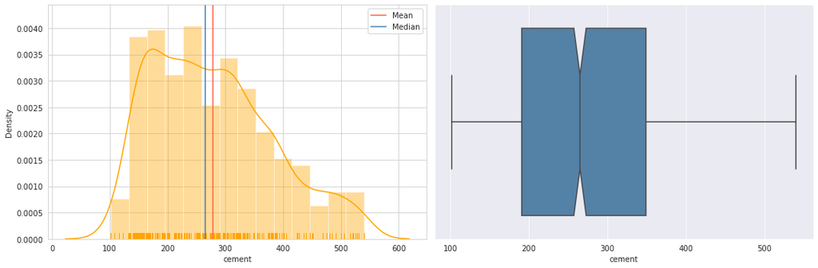

```
> Cement
 Mean         : 278.631343283582
 Median       : 265.0
Skew          : 0.5649589710818719
Lower whisker : 102.0
Upper whisker : 540.0
Outliers above upper whisker:  0 (0.0%)
Outliers under lower whisker:  0 (0.0%)
```

```python
display_num_stat_graph(cdf, 'cement', hist_color='orange')
display_num_skew_outliers(cdf, 'cement')
```

**Insights:**

- Close to normal distribution with some positive skew and no outliers.
- **Blast Furnace Slag (slag)**

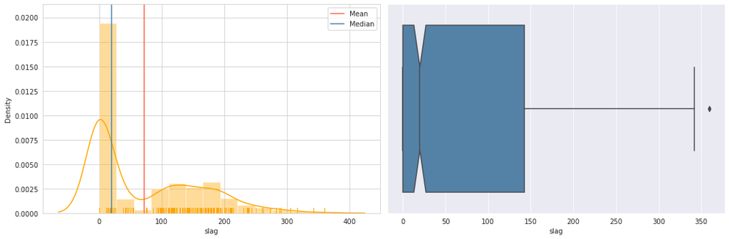

```
> Slag
 Mean         : 72.04348258706466
 Median       : 20.0
Skew          : 0.8552248976041231
Lower whisker : 0.0
Upper whisker : 356.25
Outliers above upper whisker:  2 (0.2%)
  > (closest 15): 359.4, 359.4
Outliers under lower whisker:  0 (0.0%)
```

```python
display_num_stat_graph(cdf, 'slag', hist_color='orange')
display_num_skew_outliers(cdf, 'slag')
```

**Insights:**

- Couple of outliers and 2 gausians. This can lead to unreliable Mean/Median.
- **Fly Ash (ash)**

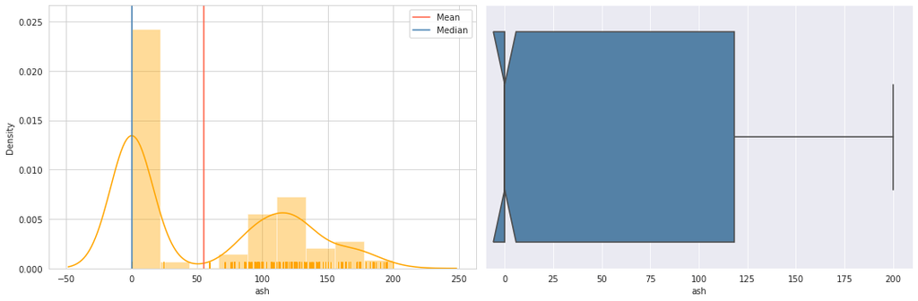

```
> Ash
 Mean         : 55.53631840796018
 Median       : 0.0
Skew          : 0.4972312662135868
Lower whisker : 0.0
Upper whisker : 200.1
Outliers above upper whisker:  0 (0.0%)
Outliers under lower whisker:  0 (0.0%)
```

```python
display_num_stat_graph(cdf, 'ash', hist_color='orange')
display_num_skew_outliers(cdf, 'ash')
```

**Insights:**

- Median is **0**, we already saw that, **50%** of values are actually **0**, which probably means that **Fly Ash** is not used in concrete mixtures very often.
- No outliers, but it looks like we have 2 gausians on our hands. This can lead to unreliable Mean/Median.
- **Water(water)**

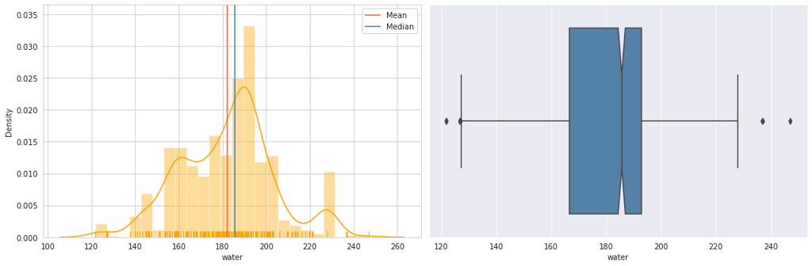

```
> Water
 Mean         : 182.07532338308457
 Median       : 185.7
Skew          : 0.03443320802163803
Lower whisker : 127.14999999999998
Upper whisker : 232.35000000000002
Outliers above upper whisker:  4 (0.4%)
  > (closest 15): 247.0, 246.9, 237.0, 236.7
Outliers under lower whisker:  11 (1.1%)
  > (closest 15): 127.0, 126.6, 121.8, 126.6, 121.8, 126.6, 126.6, 121.8, 121.8, 126.6, 121.8
```

```python
display_num_stat_graph(cdf, 'water', hist_color='orange')
display_num_skew_outliers(cdf, 'water')
```

- **Superplasticizer (superplastic)**

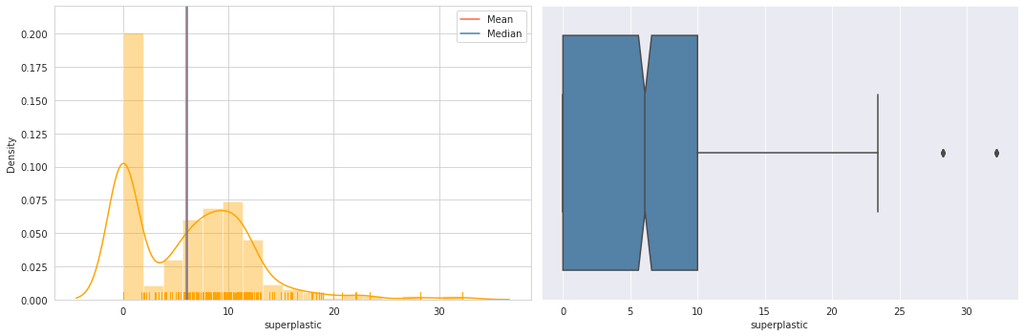

```
> Superplastic
 Mean         : 6.033233830845768
 Median       : 6.1
Skew          : 0.9806043204539714
Lower whisker : 0.0
Upper whisker : 25.0
Outliers above upper whisker:  10 (1.0%)
  > (closest 15): 28.2, 28.2, 32.2, 32.2, 28.2, 32.2, 32.2, 28.2, 32.2, 28.2
Outliers under lower whisker:  0 (0.0%)
```

```python
display_num_stat_graph(cdf, 'superplastic', hist_color='orange')
display_num_skew_outliers(cdf, 'superplastic')
```

- **Coarse Aggregate (coarseagg)**

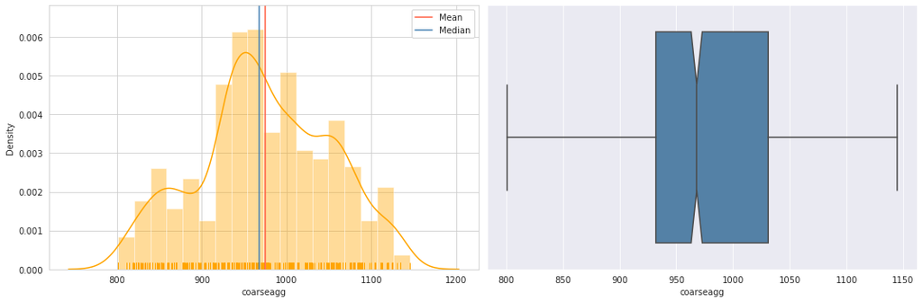

```
> Coarseagg
 Mean         : 974.3768159203987
 Median       : 968.0
Skew          : -0.06525599883507706
Lower whisker : 801.0
Upper whisker : 1145.0
Outliers above upper whisker:  0 (0.0%)
Outliers under lower whisker:  0 (0.0%)
```

```python
display_num_stat_graph(cdf, 'coarseagg', hist_color='orange')
display_num_skew_outliers(cdf, 'coarseagg')
```

**Insights:**

- No outliers, slight negative sckew.
- **Fine Aggregate (fineagg)**

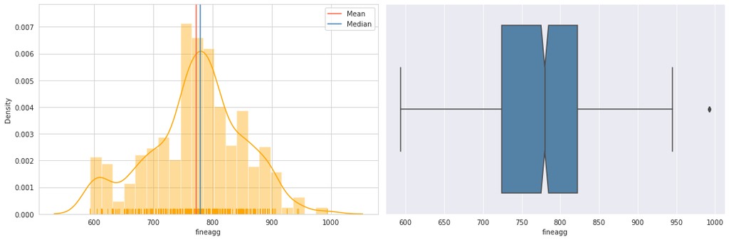

```
> Fineagg
 Mean         : 772.6882587064675
 Median       : 780.0
Skew          : -0.2523531808980051
Lower whisker : 594.0
Upper whisker : 969.0500000000002
Outliers above upper whisker:  5 (0.5%)
  > (closest 15): 992.6, 992.6, 992.6, 992.6, 992.6
Outliers under lower whisker:  0 (0.0%)
```

```python
display_num_stat_graph(cdf, 'fineagg', hist_color='orange')
display_num_skew_outliers(cdf, 'fineagg')
```

- **Age (age)**

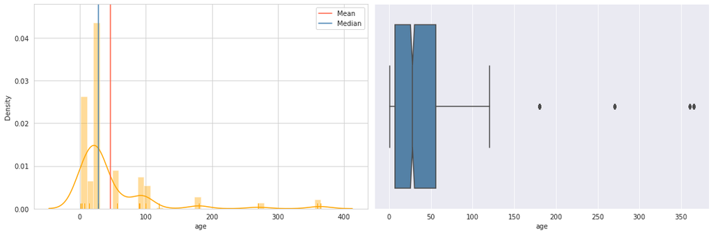

```
> Age
 Mean         : 45.85671641791045
 Median       : 28.0
Skew          : 3.253973717331205
Lower whisker : 1
Upper whisker : 129.5
Outliers above upper whisker:  59 (5.9%)
  > (closest 15): 180, 365, 180, 180, 180, 365, 180, 270, 180, 360, 365, 365, 180, 180, 270
Outliers under lower whisker:  0 (0.0%)
```

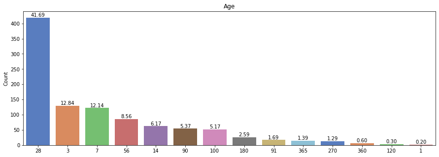

```python
display_num_stat_graph(cdf, 'age', hist_color='orange')
display_num_skew_outliers(cdf, 'age')

plt.figure(figsize=(15,5))
plot_counts_percentages(cdf, 'age')
plt.show()
```

**Insights:**

- The most common **testing agess** of concrete are: **28, 3, 7, 56** days.
- There are **59** outliers, but they are valid values.
- Concrete mixtures are tested for strength not once but several times. Hence in our dataset we expect to see several entries for the same mixture but with different testing ages and strengts.
- Usually testing times are spaced by a week (7 days) for the rapid strength gain mixtures. And so we see ages like **7, 14, 28, 56** etc. Testing age **28 days** is considered a **gold standard** in understanding a particula concrete potential, hence those samples acount almost for **42%** out of all.

```python
mixtures_df = cdf.copy()
mixtures_df.drop(['strength', 'age'], axis=1, inplace=True)
mixtures_df = mixtures_df.drop_duplicates(inplace=False, keep='first')

print(f'Unique concrete mixtures: {mixtures_df.shape[0]}')
```

```
Unique concrete mixtures: 427
```

**Insights:**

- As we can see, there are measures taken for the same concrete mixture but at different ages/times.
- **Concrete compressive strength(strength)**

Let's check target variable.

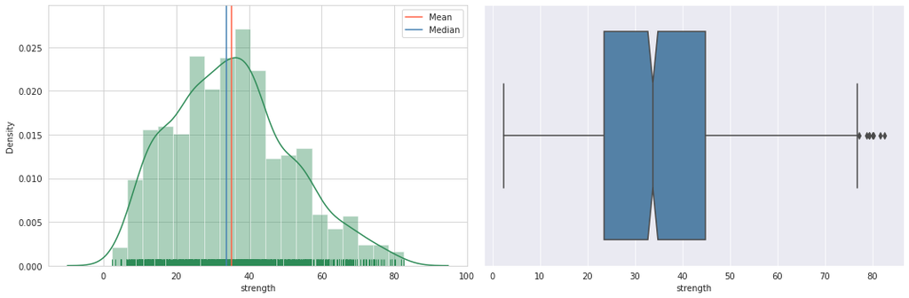

```
> Strength
 Mean         : 35.25037810945276
 Median       : 33.8
Skew          : 0.39569613431539385
Lower whisker : 2.33
Upper whisker : 76.895
Outliers above upper whisker:  8 (0.8%)
  > (closest 15): 77.3, 81.75, 79.3, 79.4, 78.8, 79.99, 82.6, 80.2
Outliers under lower whisker:  0 (0.0%)
```

```python
display_num_stat_graph(cdf, 'strength')
display_num_skew_outliers(cdf, 'strength')
```

**Insights:**

- Although we see them as outliers, M60 - M80 grade corresponds to hight strength concrete and values are valid.
- Almost perfect normal distribution with a small positive skew.

## Bivariate Analysis

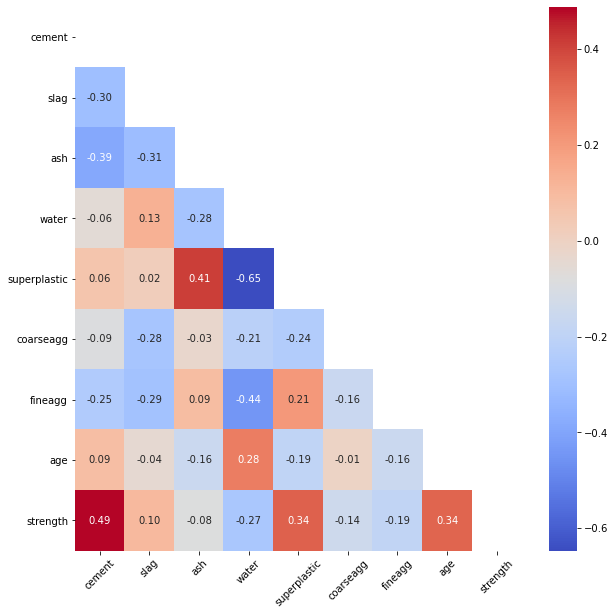

```python
plt.figure(figsize=(10,10))
mask = np.zeros_like(cdf.corr())
mask[np.triu_indices_from(mask)] = True
heatmap= sns.heatmap(cdf.corr(), annot = True, cmap='coolwarm', fmt='0.2f', cbar = True, mask=mask)
heatmap.set_xticklabels(heatmap.get_xticklabels(), rotation=45, fontweight='light')
plt.show()
```

**Insights:**

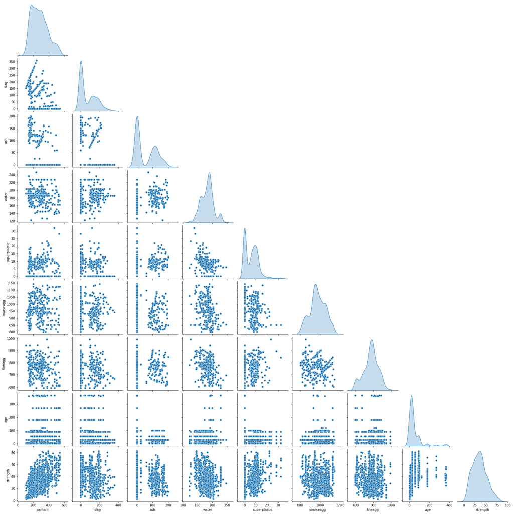

```python
sns.pairplot(cdf, corner=True, diag_kind = 'kde')
plt.show()
```

**Insights:**

- **slag**, **ash** and **superplastic** have **2** very prominent Gaussians. Each of these **3 aggregates** is an **optional component** in the concrete and so the first Gaussian is related to the case when it is not used. Splitting the dataset might help getting better prediction results out of the models.
- And **water** and **coarseagg** may have **3** mixed Gaussians.
- We see again that there are no strong predictors. Only visually noticable light linear correlation is between **cement** and target variable **strength**. Also **age** has definite correlation with the compressive strength, we see that aged cocrete is never weak.

## Feature Engineering

We already removed duplicates so they won't affect our further investigation.

We don't have missing values in this dataset, but we have outliers. Let's deal with them first.

### Define Utility Functions

```python
def treat_outliers(series, fix_strategy='median', detect_strategy='IQR'):
    lower = 0
    upper = 0
    s = series.copy()

    # Detection
    if(detect_strategy == 'IQR'):
        Q1 = s.quantile(0.25)
        Q3 = s.quantile(0.75)
        IQR = Q3 - Q1
        lower = Q1 - 1.5 * IQR
        upper = Q3 + 1.5 * IQR
    elif(detect_strategy == 'CAPPING'):
        mean = s.mean()
        std = s.std()
        lower = mean - 2 * std
        upper = mean + 2 * std
    else:
         raise Exception(f'Unknown detect_strate "{detect_strategy}"')

    # Replacement
    if(fix_strategy == 'median'):
        median = s.median()
        s[(s < lower) | (s > upper)] = median
    elif(fix_strategy == 'mean'):
        mean = series.mean()
        s[(s < lower) | (s > upper)] = mean
    elif(fix_strategy == 'capping'):
        s[s < lower] = lower
        s[s > upper] = upper
    else:
         raise Exception(f'Unknown fix_strategy "{fix_strategy}"')

    return s

def boxplot_grid(data, columns, nrows, ncols):
    plt.figure(figsize=(17,15))
    index = 1
    for col in columns:
        with sns.axes_style("darkgrid"):
            plt.subplot(nrows, ncols, index)
            sns.boxplot(data[col], notch = True, whis = 1.5, color='steelblue')
        index += 1
    plt.show()
```

```python
from sklearn.metrics import r2_score, mean_squared_error
from sklearn.model_selection import KFold
from sklearn.model_selection import cross_val_score

seed = 33

def get_percentage(df, subset):
    return len(subset)/len(df.index) * 100

def adjusted_r_squared(est, pX, py):
    r2 = est.score(pX, py)  # should be R2 score
    return 1 - (1 - r2) * (len(py) - 1) / (len(py) - pX.shape[1] - 1)

def reg_metrics(est, pX_train, pX_test, py_train, py_test):
    # R-squared
    # the coefficient of determination. It is the proportion of the variance in the dependent variable that is predictable/explained.
    # R^2 is not a reliable metric as it always increases with addition of more attributes even if the attributes have no
    # influence on the predicted variable.
    #
    # Adj. R-squared
    # is the modified form of R-squared adjusted for the number of independent variables in the model.

    py_pred = est.predict(pX_test)
    r2_train = est.score(pX_train, py_train)
    r2_test = est.score(pX_test, py_test)
    adj_r2_train = adjusted_r_squared(est, pX_train, py_train)
    adj_r2_test = adjusted_r_squared(est, pX_test, py_test)

    return {'r2_train': r2_train,
        'r2_test': r2_test,
        'r2_delta': abs(r2_train - r2_test),
        'r2_test_v2': r2_score(py_test, py_pred),
        'adj_r2_train': adj_r2_train,
        'adj_r2_test': adj_r2_test,
        'adj_r2_delta': abs(adj_r2_train - adj_r2_test),
        'RMSE_test': np.sqrt(mean_squared_error(py_test, py_pred))
    }

def calc_ci95(scores):
    mean = scores.mean()
    std = scores.std()
    z_025 = 1.96   # critical value, a/2 = 0.5/2 = 0.025

    lower = mean - z_025 * std / np.sqrt(len(scores))
    upper = mean + z_025 * std / np.sqrt(len(scores))
    return (lower, upper)

def calc_percentile_95_range(scores):
    alpha = 0.95                             # for 95% confidence
    p = ((1.0-alpha)/2.0) * 100              # tail regions on right and left .25 on each side indicated by P value (border)
    lower = max(0.0, np.percentile(scores, p))
    p = (alpha+((1.0-alpha)/2.0)) * 100
    upper = min(1.0, np.percentile(scores, p))

    return (lower, upper)

def kfold_metrics(estimator, pX_train, py_train, num_folds=10, scoring=None):
        cv_alg = KFold(n_splits=num_folds, random_state=seed)

        # Options for scoring:
        # - 'neg_root_mean_squared_error' for metrics.mean_squared_error
        # - 'r2' for metrics.r2_score
        # - or a scorer callable object / function with signature scorer(estimator, X, y) which should return only a single value.
        scoring_method = 'r2'
        if(scoring == 'adj_r2'):
            scoring_method = adjusted_r_squared

        scores = cross_val_score(estimator, pX_train, py_train, cv=cv_alg, scoring=scoring_method)

        return {
            'count': len(scores),
            'mean': scores.mean(),
            'std': scores.std(),
            'ci95': calc_ci95(scores),
            'percentile95': calc_percentile_95_range(scores)
        }


def get_reg_report(metrics, title, kfold_scoring):
    return pd.DataFrame(
        [[
            metrics["r2_train"],
            metrics["r2_test"],
            metrics["r2_delta"],
            metrics["adj_r2_train"],
            metrics["adj_r2_test"],
            metrics["adj_r2_delta"],
            f'{metrics["mean"]:.4f} \u00B1 {metrics["std"]:.2f}',
            f'{metrics["ci95"][0]:.4f} - {metrics["ci95"][1]:.4f}',
            f'{metrics["percentile95"][0]:.4f} - {metrics["percentile95"][1]:.4f}',
            metrics["RMSE_test"]]],
        columns=[
            'R\u00B2 train',
            'R\u00B2 test',
            '\u0394 R\u00B2',
            'Adj.R\u00B2 train',
            'Adj.R\u00B2 test',
            '\u0394 Adj.R\u00B2',
            'KFold Adj.R\u00B2 CV' if kfold_scoring == 'adj_r2' else 'KFold R\u00B2',
            'ci95 CV',
            'class95 CV',
            'RSME test'
        ],
        index=[title]
    )

def print_fi_coeff(est, pX_train):
    coeff = []
    if hasattr(est, 'feature_importances_'):
        coeff = est.feature_importances_
    elif hasattr(est, 'coef_'):
        coeff = abs(est.coef_)

    if len(coeff) > 0:
        fi_df = pd.DataFrame(coeff, columns = ['Importance'], index = pX_train.columns).sort_values(by='Importance', ascending=False).reset_index()
        fi_df.rename(columns = {'index': 'Feature'}, inplace=True)
        display(fi_df)
```

```python
from sklearn.linear_model import LinearRegression
from sklearn.linear_model import Lasso
from sklearn.linear_model import Ridge
from sklearn.neighbors import KNeighborsRegressor
from sklearn.svm import SVR
from sklearn.tree import DecisionTreeRegressor
from sklearn.ensemble import RandomForestRegressor
from sklearn.ensemble import BaggingRegressor
from sklearn.ensemble import GradientBoostingRegressor
from sklearn.ensemble import AdaBoostRegressor
from xgboost.sklearn import XGBRegressor
from sklearn.model_selection import train_test_split

def estimator_factory(estimator):
    if(estimator == 'LinearRegression'):
        return LinearRegression(fit_intercept=True)
    elif(estimator == 'Lasso'):
        return Lasso(random_state=seed)
    elif(estimator == 'Ridge'):
        return Ridge(random_state=seed)
    elif(estimator == 'KNeighborsRegressor'):
        return KNeighborsRegressor(n_neighbors=4)
    elif(estimator == 'SVR'):
        return SVR(C=6000, epsilon=0.0001)
    elif(estimator == 'DecisionTreeRegressor'):
        return DecisionTreeRegressor(criterion='friedman_mse', max_depth=19, min_samples_split=6, max_features=None, random_state=seed)
    elif(estimator == 'RandomForestRegressor'):
        return RandomForestRegressor(random_state=seed)
    elif(estimator == 'BaggingRegressor'):
        return BaggingRegressor(random_state=seed)
    elif(estimator == 'GradientBoostingRegressor'):
        return GradientBoostingRegressor(random_state=seed)
    elif(estimator == 'AdaBoostRegressor'):
        return AdaBoostRegressor(n_estimators=100, random_state=seed)
    elif(estimator == 'XGBRegressor'):
        return XGBRegressor(objective ='reg:squarederror', n_estimators = 90, max_depth=5, eta=0.32, subsample=1, colsample_bytree=1, seed=seed)
    else:
         raise Exception(f'Unknown estimator "{estimator}"')

def run_estimators(data, estimators, options={'kfold':'r2'}):
    X = data.drop('strength', axis=1)
    Y = data['strength']
    X_train, X_test, y_train, y_test = train_test_split(X, Y, test_size=0.30, random_state=seed)
    reports=[]

    for estimator_name in estimators:
        if type(estimator_name) is dict:
            estimator = estimator_name['regressor']
            title = estimator_name['title']
        else:
            if 'pipe_factory' in options:
                pipe_factory = options['pipe_factory']
                estimator = pipe_factory(estimator_factory(estimator_name))
                title = f'{estimator_name}_{options["pipe_name"]}'
            else:
                estimator = estimator_factory(estimator_name)
                title = f'{estimator_name}_{options["suff"]}' if 'suff' in options else estimator_name

        estimator.fit(X_train, y_train)
        m1 = reg_metrics(estimator, X_train, X_test, y_train, y_test)
        m2 = kfold_metrics(estimator, X, Y, scoring=options['kfold'])
        metrics = {**m1, **m2}
        reports.append(get_reg_report(metrics, title, kfold_scoring=options['kfold']))

    return pd.concat(reports, sort=False)

def run_custom_estimators(estimator, pX, pY, pX_train, pX_test, py_train, py_test, title, options={'kfold':'r2'}):
    estimator.fit(pX_train, py_train)
    m1 = reg_metrics(estimator, pX_train, pX_test, py_train, py_test)
    m2 = kfold_metrics(estimator, pX, pY, scoring=options['kfold'])
    metrics = {**m1, **m2}

    return get_reg_report(metrics, title, kfold_scoring=options['kfold'])
```

### Dealing with the Outliers

In order to validate our outlier treatment technique we will run a set of basic regressors and compare their performance metrics (R^2 and Adj. R^2).

Let's print out what we have now.

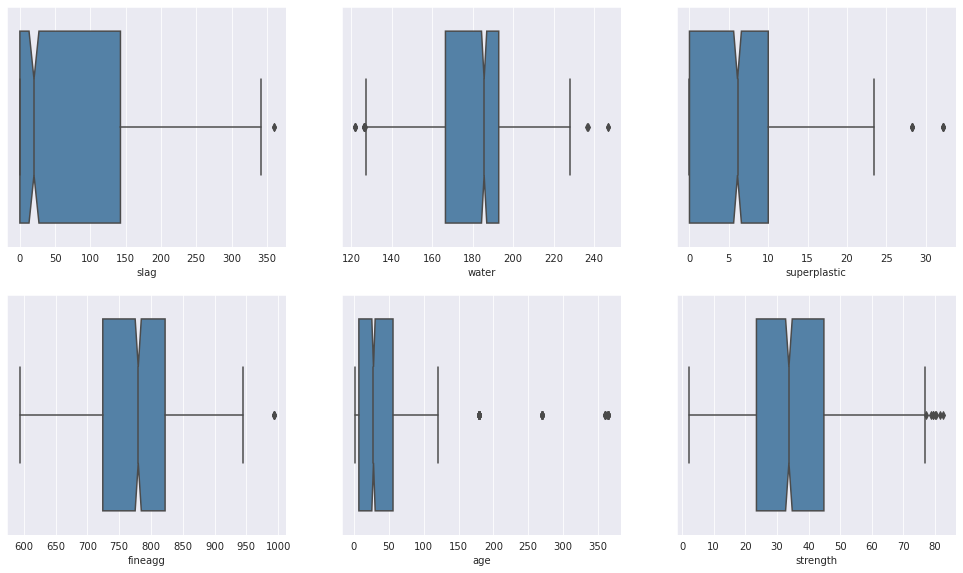

|  | R² train | R² test | Δ R² | Adj.R² train | Adj.R² test | Δ Adj.R² | KFold Adj.R² CV | ci95 CV | class95 CV | RSME test |
| --- | --- | --- | --- | --- | --- | --- | --- | --- | --- | --- |
| LinearRegression | 0.5963 | 0.5903 | 0.0060 | 0.5917 | 0.5792 | 0.0125 | 0.5400 ± 0.09 | 0.4848 - 0.5953 | 0.4193 - 0.6816 | 10.8748 |
| Lasso | 0.5961 | 0.5910 | 0.0051 | 0.5914 | 0.5798 | 0.0117 | 0.5398 ± 0.09 | 0.4853 - 0.5943 | 0.4186 - 0.6772 | 10.8666 |
| Ridge | 0.5963 | 0.5903 | 0.0060 | 0.5917 | 0.5792 | 0.0125 | 0.5400 ± 0.09 | 0.4848 - 0.5953 | 0.4193 - 0.6816 | 10.8748 |
| KNeighborsRegressor | 0.8060 | 0.7022 | 0.1038 | 0.8038 | 0.6940 | 0.1097 | 0.6633 ± 0.08 | 0.6162 - 0.7104 | 0.5295 - 0.7581 | 9.2722 |
| SVR | 0.8060 | 0.7832 | 0.0228 | 0.8037 | 0.7773 | 0.0265 | 0.7660 ± 0.05 | 0.7352 - 0.7968 | 0.7022 - 0.8631 | 7.9115 |
| DecisionTreeRegressor | 0.9796 | 0.8361 | 0.1435 | 0.9794 | 0.8317 | 0.1477 | 0.8320 ± 0.05 | 0.8020 - 0.8620 | 0.7517 - 0.9009 | 6.8778 |
| RandomForestRegressor | 0.9812 | 0.8969 | 0.0843 | 0.9810 | 0.8940 | 0.0869 | 0.8988 ± 0.03 | 0.8779 - 0.9198 | 0.8349 - 0.9457 | 5.4566 |
| BaggingRegressor | 0.9748 | 0.8823 | 0.0926 | 0.9745 | 0.8790 | 0.0955 | 0.8937 ± 0.04 | 0.8668 - 0.9205 | 0.7978 - 0.9376 | 5.8299 |
| GradientBoostingRegressor | 0.9501 | 0.8862 | 0.0639 | 0.9495 | 0.8831 | 0.0664 | 0.8895 ± 0.02 | 0.8754 - 0.9035 | 0.8587 - 0.9259 | 5.7316 |
| AdaBoostRegressor | 0.8280 | 0.7840 | 0.0439 | 0.8260 | 0.7781 | 0.0479 | 0.7598 ± 0.04 | 0.7369 - 0.7827 | 0.6945 - 0.8181 | 7.8956 |
| XGBRegressor | 0.9934 | 0.9173 | 0.0761 | 0.9933 | 0.9150 | 0.0783 | 0.9201 ± 0.03 | 0.9002 - 0.9399 | 0.8562 - 0.9616 | 4.8868 |

```python
boxplot_grid(cdf, ['slag', 'water', 'superplastic', 'fineagg', 'age', 'strength'], 3, 3)

report = run_estimators(cdf, [
    'LinearRegression',
    'Lasso',
    'Ridge',
    'KNeighborsRegressor',
    'SVR',
    'DecisionTreeRegressor',
    'RandomForestRegressor',
    'BaggingRegressor',
    'GradientBoostingRegressor',
    'AdaBoostRegressor',
    'XGBRegressor'], options={'kfold':'adj_r2'})
display(report)
```

Now let's treat the outliers.

```python
df_no_outliers = cdf.copy()
for col in ['slag', 'water', 'superplastic', 'fineagg', 'age', 'strength']:
    df_no_outliers[col] = treat_outliers(cdf[col], fix_strategy='capping', detect_strategy='CAPPING')
```

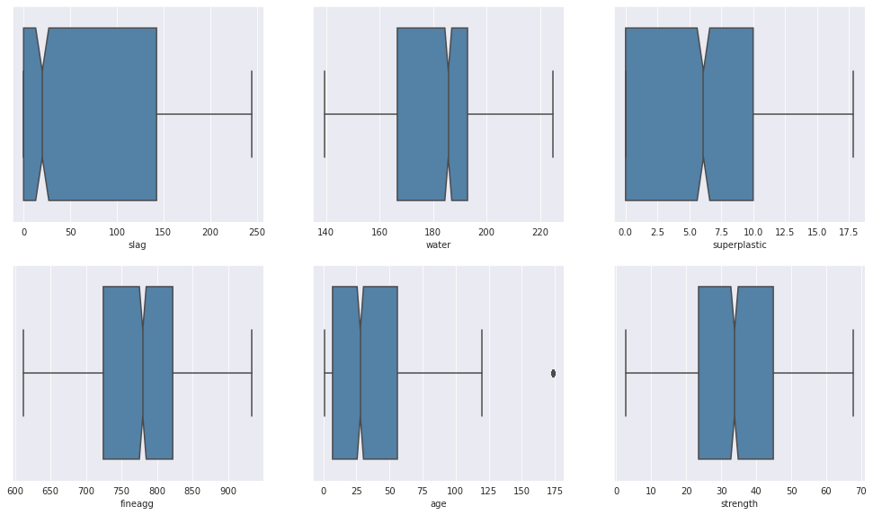

|  | R² train | R² test | Δ R² | Adj.R² train | Adj.R² test | Δ Adj.R² | KFold Adj.R² CV | ci95 CV | class95 CV | RSME test |
| --- | --- | --- | --- | --- | --- | --- | --- | --- | --- | --- |
| LinearRegression | 0.6811 | 0.6948 | 0.0137 | 0.6775 | 0.6865 | 0.0090 | 0.6431 ± 0.08 | 0.5957 - 0.6905 | 0.5408 - 0.7687 | 9.1720 |
| Lasso | 0.6808 | 0.6957 | 0.0149 | 0.6771 | 0.6874 | 0.0103 | 0.6429 ± 0.08 | 0.5963 - 0.6895 | 0.5409 - 0.7648 | 9.1577 |
| Ridge | 0.6811 | 0.6948 | 0.0137 | 0.6775 | 0.6865 | 0.0090 | 0.6431 ± 0.08 | 0.5957 - 0.6905 | 0.5408 - 0.7687 | 9.1719 |
| KNeighborsRegressor | 0.8186 | 0.7115 | 0.1071 | 0.8165 | 0.7036 | 0.1129 | 0.6783 ± 0.07 | 0.6322 - 0.7245 | 0.5636 - 0.7728 | 8.9174 |
| SVR | 0.8385 | 0.8131 | 0.0255 | 0.8367 | 0.8080 | 0.0287 | 0.7972 ± 0.04 | 0.7705 - 0.8240 | 0.7326 - 0.8716 | 7.1784 |
| DecisionTreeRegressor | 0.9809 | 0.8235 | 0.1575 | 0.9807 | 0.8186 | 0.1621 | 0.8398 ± 0.05 | 0.8101 - 0.8695 | 0.7573 - 0.9060 | 6.9756 |
| RandomForestRegressor | 0.9819 | 0.8974 | 0.0846 | 0.9817 | 0.8946 | 0.0871 | 0.9052 ± 0.03 | 0.8861 - 0.9242 | 0.8403 - 0.9399 | 5.3191 |
| BaggingRegressor | 0.9748 | 0.8808 | 0.0940 | 0.9745 | 0.8775 | 0.0970 | 0.8974 ± 0.04 | 0.8715 - 0.9233 | 0.8043 - 0.9384 | 5.7329 |
| GradientBoostingRegressor | 0.9473 | 0.8935 | 0.0538 | 0.9467 | 0.8906 | 0.0562 | 0.8959 ± 0.02 | 0.8836 - 0.9083 | 0.8646 - 0.9279 | 5.4188 |
| AdaBoostRegressor | 0.8243 | 0.7839 | 0.0404 | 0.8223 | 0.7780 | 0.0443 | 0.7761 ± 0.03 | 0.7552 - 0.7971 | 0.7072 - 0.8079 | 7.7176 |
| XGBRegressor | 0.9930 | 0.9198 | 0.0732 | 0.9930 | 0.9176 | 0.0753 | 0.9221 ± 0.03 | 0.9035 - 0.9408 | 0.8556 - 0.9537 | 4.7011 |

```python
boxplot_grid(df_no_outliers, ['slag', 'water', 'superplastic', 'fineagg', 'age', 'strength'], 3, 3)

report = run_estimators(df_no_outliers, [
    'LinearRegression',
    'Lasso',
    'Ridge',
    'KNeighborsRegressor',
    'SVR',
    'DecisionTreeRegressor',
    'RandomForestRegressor',
    'BaggingRegressor',
    'GradientBoostingRegressor',
    'AdaBoostRegressor',
    'XGBRegressor'], options={'kfold':'adj_r2'})
display(report)
```

**Insights:**

- There are still some outliers for the **age**, but we will stop biasing the data any furter.
- As we can see from the final report, out of all combinations **capping** thechnique gives the best scores on the basic set of regressors.

**Applying feature.**

```python
cdf = df_no_outliers
```

### Slag, Ash, Superplastic - Binarization

As we saw in our previous analysis, all these 3 attributes have double Gausians. This is because these aggregates are actually optional components for the concrete. Many rows in out data set have them as **0**.

Let's try and introduce binary attributes which will indicate if a particular component is in or out. Also we can try creating an aggregate attribute which indicates which of 3 components is in the mix.

In order to validate the results we will run a set of basic regressors as we did earlier for outliers.

```python
from sklearn.preprocessing import Binarizer

transformer = Binarizer()

bin_att_df = cdf.copy()
bin_att_df['slag_b'] = transformer.fit_transform(bin_att_df['slag'].to_numpy().reshape(1, -1)).reshape(-1, 1)
bin_att_df['slag_b'] = bin_att_df['slag_b'].astype('bool')
bin_att_df['ash_b'] = transformer.fit_transform(bin_att_df['ash'].to_numpy().reshape(1, -1)).reshape(-1, 1)
bin_att_df['ash_b'] = bin_att_df['ash_b'].astype('bool')
bin_att_df['superplastic_b'] = transformer.fit_transform(bin_att_df['superplastic'].to_numpy().reshape(1, -1)).reshape(-1, 1)
bin_att_df['superplastic_b'] = bin_att_df['superplastic_b'].astype('bool')
bin_att_df['sum'] = bin_att_df['slag_b'].astype(int).astype(str)+'_'+bin_att_df['ash_b'].astype(int).astype(str)+'_'+bin_att_df['superplastic_b'].astype(int).astype(str)
bin_att_df = pd.get_dummies(bin_att_df, columns=['sum'], drop_first=True)
#bin_att_df.drop(['slag', 'ash', 'superplastic'], inplace=True, axis=1)
#bin_att_df.drop(['slag', 'ash', 'superplastic', 'slag_b', 'ash_b', 'superplastic_b'], inplace=True, axis=1)
bin_att_df.drop(['slag_b', 'ash_b', 'superplastic_b'], inplace=True, axis=1)
bin_att_df.head()
```

|  | cement | slag | ash | water | superplastic | coarseagg | fineagg | age | strength | sum_0_0_1 | sum_0_1_0 | sum_0_1_1 | sum_1_0_0 | sum_1_0_1 | sum_1_1_1 |
| --- | --- | --- | --- | --- | --- | --- | --- | --- | --- | --- | --- | --- | --- | --- | --- |
| 0 | 141.3000 | 212.0000 | 0.0000 | 203.5000 | 0.0000 | 971.8000 | 748.5000 | 28.0000 | 29.8900 | 0 | 0 | 0 | 1 | 0 | 0 |
| 1 | 168.9000 | 42.2000 | 124.3000 | 158.3000 | 10.8000 | 1080.8000 | 796.2000 | 14.0000 | 23.5100 | 0 | 0 | 0 | 0 | 0 | 1 |
| 2 | 250.0000 | 0.0000 | 95.7000 | 187.4000 | 5.5000 | 956.9000 | 861.2000 | 28.0000 | 29.2200 | 0 | 0 | 1 | 0 | 0 | 0 |
| 3 | 266.0000 | 114.0000 | 0.0000 | 224.7540 | 0.0000 | 932.0000 | 670.0000 | 28.0000 | 45.8500 | 0 | 0 | 0 | 1 | 0 | 0 |
| 4 | 154.8000 | 183.4000 | 0.0000 | 193.3000 | 9.1000 | 1047.4000 | 696.7000 | 28.0000 | 18.2900 | 0 | 0 | 0 | 0 | 1 | 0 |

```python
report = run_estimators(bin_att_df, [
    'LinearRegression',
    'Lasso',
    'Ridge',
    'KNeighborsRegressor',
    'SVR',
    'DecisionTreeRegressor',
    'RandomForestRegressor',
    'BaggingRegressor',
    'GradientBoostingRegressor',
    'AdaBoostRegressor',
    'XGBRegressor'], options={'kfold':'adj_r2'})
display(report)
```

|  | R² train | R² test | Δ R² | Adj.R² train | Adj.R² test | Δ Adj.R² | KFold Adj.R² CV | ci95 CV | class95 CV | RSME test |
| --- | --- | --- | --- | --- | --- | --- | --- | --- | --- | --- |
| LinearRegression | 0.7133 | 0.7179 | 0.0046 | 0.7075 | 0.7042 | 0.0033 | 0.6480 ± 0.09 | 0.5953 - 0.7007 | 0.5302 - 0.7849 | 8.8178 |
| Lasso | 0.6808 | 0.6957 | 0.0149 | 0.6743 | 0.6809 | 0.0066 | 0.6178 ± 0.08 | 0.5679 - 0.6677 | 0.5088 - 0.7484 | 9.1577 |
| Ridge | 0.7126 | 0.7157 | 0.0032 | 0.7067 | 0.7019 | 0.0049 | 0.6477 ± 0.08 | 0.5956 - 0.6998 | 0.5321 - 0.7839 | 8.8516 |
| KNeighborsRegressor | 0.8186 | 0.7115 | 0.1071 | 0.8149 | 0.6974 | 0.1175 | 0.6558 ± 0.08 | 0.6064 - 0.7052 | 0.5329 - 0.7569 | 8.9174 |
| SVR | 0.8287 | 0.8102 | 0.0185 | 0.8252 | 0.8010 | 0.0242 | 0.7730 ± 0.05 | 0.7440 - 0.8021 | 0.7051 - 0.8547 | 7.2326 |
| DecisionTreeRegressor | 0.9807 | 0.8327 | 0.1479 | 0.9803 | 0.8246 | 0.1557 | 0.8309 ± 0.05 | 0.7999 - 0.8618 | 0.7461 - 0.8849 | 6.7904 |
| RandomForestRegressor | 0.9819 | 0.8994 | 0.0824 | 0.9815 | 0.8945 | 0.0870 | 0.8983 ± 0.03 | 0.8776 - 0.9191 | 0.8267 - 0.9366 | 5.2651 |
| BaggingRegressor | 0.9745 | 0.8769 | 0.0976 | 0.9740 | 0.8709 | 0.1031 | 0.8895 ± 0.05 | 0.8611 - 0.9178 | 0.7863 - 0.9274 | 5.8253 |
| GradientBoostingRegressor | 0.9484 | 0.8950 | 0.0534 | 0.9474 | 0.8899 | 0.0575 | 0.8871 ± 0.02 | 0.8731 - 0.9010 | 0.8508 - 0.9221 | 5.3786 |
| AdaBoostRegressor | 0.8180 | 0.7663 | 0.0517 | 0.8143 | 0.7549 | 0.0594 | 0.7613 ± 0.04 | 0.7370 - 0.7856 | 0.6941 - 0.8160 | 8.0266 |
| XGBRegressor | 0.9929 | 0.9210 | 0.0719 | 0.9928 | 0.9172 | 0.0756 | 0.9214 ± 0.03 | 0.9008 - 0.9420 | 0.8479 - 0.9560 | 4.6649 |

**Insights:**

**Wi will use this feature, but not for all models.**

```python
cdf_bin_att = bin_att_df
```

### Age vs Strength

As we know already we have several measures taken for the same concrete mixture at different moments in time (age). So let us plot age/strength graphs for the mixtures with enough samples.

Just to limit the number of items to show, we will print first 10 charts which have more than 4 age samples, that have no several samples for the same age and max age < 300.

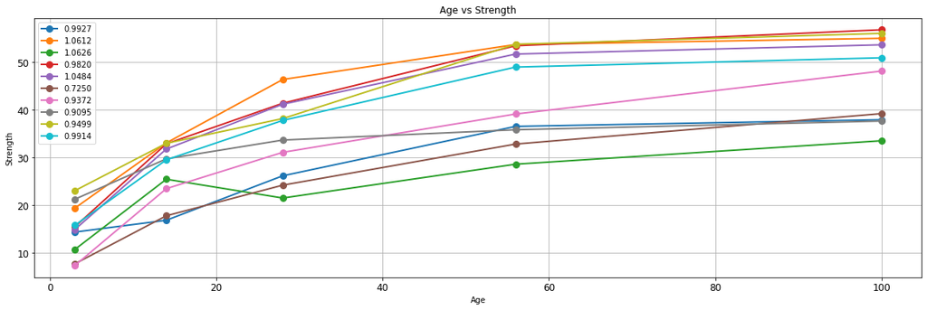

```python
tdf = df.drop_duplicates(inplace=False, keep='first')
res = tdf.groupby(['cement', 'slag', 'ash', 'water', 'superplastic', 'coarseagg', 'fineagg'])

f, ax = plt.subplots(1, 1, figsize=(20, 6))

count=10
for key, gdf in res:
    p_count = len(gdf)

    if(p_count > 4 and len(gdf['age'].unique()) == p_count and gdf['age'].max() < 300):
        gdf_sorted = gdf.sort_values(by='age', ascending=False)
        temp_gdf = gdf_sorted.reset_index()
        ratio = (temp_gdf['water']/temp_gdf['cement'])[0];

        ax.plot(gdf_sorted['age'], gdf_sorted['strength'], marker='o', linewidth=2, markersize=8, label=f'{ratio:.04f}', linestyle="-")
        count -= 1
        if(count == 0):
            break

ax.legend()
ax.set_title('Age vs Strength')
ax.set_xlabel('Age')
ax.set_ylabel('Strength')
plt.tick_params(axis='both', which='both', labelsize=12)
plt.grid(True)
plt.show()
```

Let's display some problematic samples.

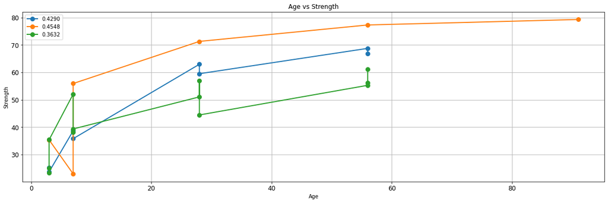

```python
f, ax = plt.subplots(1, 1, figsize=(20, 6))

for key, gdf in res:
    p_count = len(gdf)

    if(len(gdf['age'].unique()) != p_count):
        gdf_sorted = gdf.sort_values(by='age', ascending=False)
        temp_gdf = gdf_sorted.reset_index()
        ratio = (temp_gdf['water']/temp_gdf['cement'])[0];

        ax.plot(gdf_sorted['age'], gdf_sorted['strength'], marker='o', linewidth=2, markersize=8, label=f'{ratio:.04f}', linestyle="-")

ax.legend()
ax.set_title('Age vs Strength')
ax.set_xlabel('Age')
ax.set_ylabel('Strength')
plt.tick_params(axis='both', which='both', labelsize=12)
plt.grid(True)
plt.show()
```

**Insights:**

- Now we can see that there is a definite mathematical equesion between **age** and **strength**. Concrete becomes stronger with time.
- Also by looking at that **orange**, **green** and **blue** lines (second chart) we can notice that for the same age they have several values of strength, this indicates that the same type of concrete mixture was tested in different times/places with a little bit different outcome results. These kind of cases can be easily detaced and addressed. However there can be cases when ages do not repeat but it is still a mix from different places/times (see **green** line on the first chart), this kind is not easily detectable.
- If we knew the formula (looks like a logarithmic equation) that can become a very good predictor. We can use this knowledge to expand our dataset on missging ages, so we can generate more data based of math formula, which should defenetely help our models. But this thechnique will reqiure more time to implement correctly, so we should see first if it is worth the time spent. Plus there some issues to overcome. Firstly we don't have any attribute which can help us to separate same mixtures with different results. Secondly there are other unknown factors that move those lines up and down on the strength axis.

### Age - Binning

As we so before testing **age** can be very important. Right know it has a distribution far from normal and big skew. Let's try binning it to improve the matters and help the algorithms.

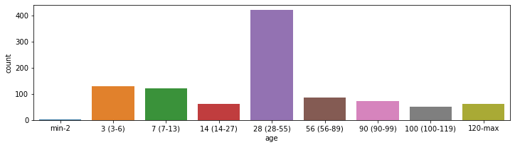

```
> Age_Cat
 Mean         : 3.9313432835820894
 Median       : 4.0
Skew          : 0.3146287597529136
Lower whisker : 0
Upper whisker : 8
Outliers above upper whisker:  0 (0.0%)
Outliers under lower whisker:  0 (0.0%)
```

```python
age_bin_df = cdf.copy()
age_cat = pd.cut(
    age_bin_df['age'],
    bins=[age_bin_df['age'].min(), 3-1, 7-1, 14-1, 28-1, 56-1, 90-1, 100-1, 120-1, age_bin_df['age'].max()],
    labels=['min-2','3 (3-6)', '7 (7-13)', '14 (14-27)', '28 (28-55)', '56 (56-89)', '90 (90-99)', '100 (100-119)', '120-max'],
    include_lowest=True)
age_bin_df['age_cat'] = age_cat

plt.figure(figsize=(12,3))
sns.countplot(age_cat)
plt.show()

age_bin_df.replace({'min-2':0,'3 (3-6)':1, '7 (7-13)':2, '14 (14-27)':3, '28 (28-55)':4, '56 (56-89)':5, '90 (90-99)':6, '100 (100-119)':7, '120-max':8}, inplace = True)
display_num_skew_outliers(age_bin_df, 'age_cat')
```

```python
report = run_estimators(age_bin_df, [
    'LinearRegression',
    'Lasso',
    'Ridge',
    'KNeighborsRegressor',
    'SVR',
    'DecisionTreeRegressor',
    'RandomForestRegressor',
    'BaggingRegressor',
    'GradientBoostingRegressor',
    'AdaBoostRegressor',
    'XGBRegressor'], options={'kfold':'adj_r2'})
display(report)
```

|  | R² train | R² test | Δ R² | Adj.R² train | Adj.R² test | Δ Adj.R² | KFold Adj.R² CV | ci95 CV | class95 CV | RSME test |
| --- | --- | --- | --- | --- | --- | --- | --- | --- | --- | --- |
| LinearRegression | 0.8290 | 0.8218 | 0.0072 | 0.8268 | 0.8163 | 0.0104 | 0.8012 ± 0.03 | 0.7800 - 0.8225 | 0.7442 - 0.8472 | 7.0078 |
| Lasso | 0.8207 | 0.8133 | 0.0074 | 0.8184 | 0.8075 | 0.0109 | 0.7914 ± 0.04 | 0.7665 - 0.8164 | 0.7302 - 0.8495 | 7.1746 |
| Ridge | 0.8290 | 0.8218 | 0.0072 | 0.8268 | 0.8163 | 0.0105 | 0.8012 ± 0.03 | 0.7799 - 0.8225 | 0.7442 - 0.8473 | 7.0083 |
| KNeighborsRegressor | 0.8187 | 0.7130 | 0.1057 | 0.8164 | 0.7042 | 0.1122 | 0.6769 ± 0.08 | 0.6296 - 0.7243 | 0.5588 - 0.7717 | 8.8942 |
| SVR | 0.8504 | 0.8257 | 0.0247 | 0.8485 | 0.8203 | 0.0282 | 0.8162 ± 0.04 | 0.7915 - 0.8408 | 0.7545 - 0.8854 | 6.9316 |
| DecisionTreeRegressor | 0.9809 | 0.8201 | 0.1608 | 0.9807 | 0.8146 | 0.1661 | 0.8357 ± 0.05 | 0.8059 - 0.8656 | 0.7495 - 0.9043 | 7.0419 |
| RandomForestRegressor | 0.9818 | 0.8978 | 0.0840 | 0.9816 | 0.8947 | 0.0869 | 0.9039 ± 0.03 | 0.8845 - 0.9233 | 0.8380 - 0.9402 | 5.3066 |
| BaggingRegressor | 0.9747 | 0.8832 | 0.0916 | 0.9744 | 0.8796 | 0.0949 | 0.8970 ± 0.04 | 0.8711 - 0.9230 | 0.8043 - 0.9376 | 5.6752 |
| GradientBoostingRegressor | 0.9473 | 0.8936 | 0.0537 | 0.9466 | 0.8904 | 0.0563 | 0.8949 ± 0.02 | 0.8825 - 0.9072 | 0.8639 - 0.9271 | 5.4144 |
| AdaBoostRegressor | 0.8175 | 0.7684 | 0.0492 | 0.8152 | 0.7612 | 0.0539 | 0.7760 ± 0.03 | 0.7561 - 0.7959 | 0.7119 - 0.8079 | 7.9906 |
| XGBRegressor | 0.9930 | 0.9198 | 0.0732 | 0.9929 | 0.9173 | 0.0756 | 0.9213 ± 0.03 | 0.9024 - 0.9401 | 0.8541 - 0.9532 | 4.7011 |

**Insights:**

- By binning we reduced skewness of the **age** considerably and eliminated outliers.
- We can see that **liner regressors** have improved quite a lot by both **Adj. R^2** and **RSME** metrics.

```python
cdf_age_bin = age_bin_df
```

### Water Cement Ratio (w/c)

It is basic knowledge that when it comes to concrete, the cement and water are the two main parts that are responsible for binding the whole mixture together and they have big impact on the strength and durability of the concrete.

Let's introduce this attribute.

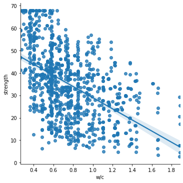

```python
wc_df = cdf.copy()
wc_df['w/c'] = wc_df['water']/wc_df['cement']

sns.lmplot(x ='w/c', y ='strength', data = wc_df)
plt.show()
```

```python
report_l = run_estimators(wc_df, [
    'LinearRegression',
    'Lasso',
    'Ridge',
    'KNeighborsRegressor',
    'SVR',
    'DecisionTreeRegressor',
    'RandomForestRegressor',
    'BaggingRegressor',
    'GradientBoostingRegressor',
    'AdaBoostRegressor',
    'XGBRegressor'], options={'kfold':'adj_r2'})
display(report_l)
```

|  | R² train | R² test | Δ R² | Adj.R² train | Adj.R² test | Δ Adj.R² | KFold Adj.R² CV | ci95 CV | class95 CV | RSME test |
| --- | --- | --- | --- | --- | --- | --- | --- | --- | --- | --- |
| LinearRegression | 0.6837 | 0.7004 | 0.0167 | 0.6796 | 0.6912 | 0.0116 | 0.6428 ± 0.08 | 0.5960 - 0.6896 | 0.5381 - 0.7717 | 9.0875 |
| Lasso | 0.6808 | 0.6957 | 0.0149 | 0.6767 | 0.6864 | 0.0097 | 0.6389 ± 0.08 | 0.5918 - 0.6861 | 0.5359 - 0.7622 | 9.1577 |
| Ridge | 0.6837 | 0.7001 | 0.0165 | 0.6796 | 0.6909 | 0.0113 | 0.6428 ± 0.08 | 0.5959 - 0.6896 | 0.5382 - 0.7716 | 9.0916 |
| KNeighborsRegressor | 0.8186 | 0.7115 | 0.1071 | 0.8163 | 0.7026 | 0.1137 | 0.6748 ± 0.08 | 0.6281 - 0.7214 | 0.5588 - 0.7702 | 8.9175 |
| SVR | 0.8354 | 0.8122 | 0.0233 | 0.8333 | 0.8064 | 0.0269 | 0.7923 ± 0.04 | 0.7653 - 0.8194 | 0.7271 - 0.8677 | 7.1956 |
| DecisionTreeRegressor | 0.9793 | 0.8334 | 0.1459 | 0.9790 | 0.8283 | 0.1508 | 0.8367 ± 0.05 | 0.8061 - 0.8674 | 0.7341 - 0.9005 | 6.7760 |
| RandomForestRegressor | 0.9822 | 0.9046 | 0.0776 | 0.9819 | 0.9016 | 0.0803 | 0.9054 ± 0.03 | 0.8838 - 0.9270 | 0.8278 - 0.9411 | 5.1291 |
| BaggingRegressor | 0.9772 | 0.8792 | 0.0980 | 0.9769 | 0.8755 | 0.1014 | 0.8918 ± 0.05 | 0.8596 - 0.9240 | 0.7760 - 0.9357 | 5.7694 |
| GradientBoostingRegressor | 0.9500 | 0.9055 | 0.0445 | 0.9494 | 0.9026 | 0.0468 | 0.8992 ± 0.02 | 0.8851 - 0.9133 | 0.8598 - 0.9324 | 5.1032 |
| AdaBoostRegressor | 0.8289 | 0.7933 | 0.0356 | 0.8267 | 0.7869 | 0.0398 | 0.7819 ± 0.03 | 0.7612 - 0.8027 | 0.7191 - 0.8289 | 7.5480 |
| XGBRegressor | 0.9924 | 0.9203 | 0.0721 | 0.9923 | 0.9179 | 0.0745 | 0.9234 ± 0.04 | 0.8962 - 0.9505 | 0.8236 - 0.9548 | 4.6868 |

**Insights:**

- We can see that **Adj. R^2** and **RSME** metrics have improved for the most regressors.

**Applying feature.**

```python
cdf_wc = wc_df
```

- **Creating feature sets**

```python
cdf_wc = wc_df # LR, RIDGE, DT, RF, GB, XGB
cdf_age_bin = age_bin_df # LR, LASSO, RIDGE, KN, SVR, BAG
cdf_bin_att = bin_att_df # LR, RIDGE, DT, RF, XGB

cdf_b_wc = cdf_bin_att.copy()
cdf_b_wc['w/c'] = cdf_wc['w/c']

cdf_all_f = cdf_bin_att.copy()
cdf_all_f['w/c'] = cdf_wc['w/c']
cdf_all_f['age_cat'] = cdf_age_bin['age_cat']

cdf_no_binary = cdf_wc.copy()
cdf_no_binary['age_cat'] = cdf_age_bin['age_cat']
```

### Polynomial Features, PCA, Scaling and Transformations

Now we will investigate transformations that should really come together. Let us try out different combinations of common and custom transformers. We will also use different feature sets for different algorithms as not all of them benefit from the same features.

We will see if transformations like StandardScaler can help us in any way. Traditionally we would use scalers to normalize attributes that use different scales and ranges. In our case, all concrete components are measured in the same way, and only age stands apart.

Also, it is very important to note one thing. If before we could apply changes across the whole dataset, now we should be very careful not to create test **data leaks** as these transformations will use mean/median/std, etc obtained using all provided data and so knowledge of the test set will leak into the train set. In order to avoid this kind of mistake, we will employ **pipelines** to achieve consistency and apply transformations separately to training and test sets.

**After multiple experiments the best combinations are as following:**

```python
from sklearn.preprocessing import PolynomialFeatures
from sklearn.preprocessing import FunctionTransformer
from sklearn.preprocessing import StandardScaler
from sklearn.compose import ColumnTransformer
from sklearn.pipeline import Pipeline
```

```python
def pipe_factory_Poly2(regressor):
    return Pipeline(steps=[
        ('preprocessor', PolynomialFeatures(degree = 2, interaction_only=True)),
        ('regressor',  regressor)
    ])
```

- **Ridge, GradientBoostingRegressor**

```python
report_RIDGE_GB = run_estimators(cdf_no_binary, ['Ridge', 'GradientBoostingRegressor'],
                                 options={'kfold':'adj_r2', 'pipe_factory': pipe_factory_Poly2, 'pipe_name':'Poly2_NB' })
display(report_RIDGE_GB)
```

|  | R² train | R² test | Δ R² | Adj.R² train | Adj.R² test | Δ Adj.R² | KFold Adj.R² CV | ci95 CV | class95 CV | RSME test |
| --- | --- | --- | --- | --- | --- | --- | --- | --- | --- | --- |
| Ridge_Poly2_NB | 0.8942 | 0.8728 | 0.0214 | 0.8927 | 0.8684 | 0.0243 | 0.8567 ± 0.04 | 0.8341 - 0.8794 | 0.7843 - 0.9096 | 5.9214 |
| GradientBoostingRegressor_Poly2_NB | 0.9642 | 0.9080 | 0.0562 | 0.9636 | 0.9048 | 0.0588 | 0.9034 ± 0.02 | 0.8879 - 0.9188 | 0.8570 - 0.9353 | 5.0363 |

- **AdaBoostRegressor**

```python
report_ADA = run_estimators(cdf_all_f, ['AdaBoostRegressor'],
                            options={'kfold':'adj_r2', 'pipe_factory': pipe_factory_Poly2, 'pipe_name':'Poly2_BWA' })
display(report_ADA)
```

|  | R² train | R² test | Δ R² | Adj.R² train | Adj.R² test | Δ Adj.R² | KFold Adj.R² CV | ci95 CV | class95 CV | RSME test |
| --- | --- | --- | --- | --- | --- | --- | --- | --- | --- | --- |
| AdaBoostRegressor_Poly2_BWA | 0.8763 | 0.8305 | 0.0459 | 0.8735 | 0.8210 | 0.0525 | 0.8057 ± 0.03 | 0.7878 - 0.8236 | 0.7653 - 0.8416 | 6.8356 |

```python
def pipe_factory_Poly3(regressor):
    return Pipeline(steps=[
        ('preprocessor', PolynomialFeatures(degree = 3, interaction_only=True)),
        ('regressor',  regressor)
    ])
```

- **Lasso**

```python
report_LASSO = run_estimators(cdf_no_binary, ['Lasso'],
                        options={'kfold':'adj_r2', 'pipe_factory': pipe_factory_Poly3, 'pipe_name':'Poly3_NB' })
display(report_LASSO)
```

|  | R² train | R² test | Δ R² | Adj.R² train | Adj.R² test | Δ Adj.R² | KFold Adj.R² CV | ci95 CV | class95 CV | RSME test |
| --- | --- | --- | --- | --- | --- | --- | --- | --- | --- | --- |
| Lasso_Poly3_NB | 0.9095 | 0.8893 | 0.0202 | 0.9082 | 0.8855 | 0.0227 | 0.8703 ± 0.03 | 0.8493 - 0.8913 | 0.8072 - 0.9205 | 5.5244 |

- **LinearRegression**

```python
report_LR = run_estimators(cdf_age_bin, ['LinearRegression'],
                        options={'kfold':'adj_r2', 'pipe_factory': pipe_factory_Poly3, 'pipe_name':'Poly3_B' })
display(report_LR)
```

|  | R² train | R² test | Δ R² | Adj.R² train | Adj.R² test | Δ Adj.R² | KFold Adj.R² CV | ci95 CV | class95 CV | RSME test |
| --- | --- | --- | --- | --- | --- | --- | --- | --- | --- | --- |
| LinearRegression_Poly3_B | 0.9258 | 0.8565 | 0.0692 | 0.9248 | 0.8521 | 0.0727 | 0.8360 ± 0.12 | 0.7626 - 0.9093 | 0.5660 - 0.9202 | 6.2887 |

```python
def pipe_factory_SS(regressor):
    return Pipeline(steps=[
        ('preprocessor', StandardScaler()),
        ('regressor',  regressor)
    ])
```

- **KNeighborsRegressor**

```python
report_KN = run_estimators(cdf_no_binary, ['KNeighborsRegressor'],
                        options={'kfold':'adj_r2', 'pipe_factory': pipe_factory_SS, 'pipe_name':'SS_NB' })
display(report_KN)
```

|  | R² train | R² test | Δ R² | Adj.R² train | Adj.R² test | Δ Adj.R² | KFold Adj.R² CV | ci95 CV | class95 CV | RSME test |
| --- | --- | --- | --- | --- | --- | --- | --- | --- | --- | --- |
| KNeighborsRegressor_SS_NB | 0.9042 | 0.8418 | 0.0624 | 0.9028 | 0.8364 | 0.0664 | 0.8338 ± 0.04 | 0.8091 - 0.8584 | 0.7679 - 0.8901 | 6.6032 |

- **Cement LOG**

We can further improve the distribution for the important attribute - **cement**.

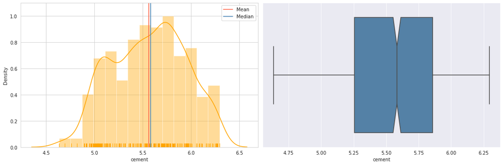

```
> Cement
 Mean         : 5.56318027620749
 Median       : 5.583496308781699
Skew          : -0.08642347748356964
Lower whisker : 4.634728988229636
Upper whisker : 6.293419278846481
Outliers above upper whisker:  0 (0.0%)
Outliers under lower whisker:  0 (0.0%)
```

```python
cdf_log = cdf.copy()
scaler_transformer = FunctionTransformer(np.log1p, validate=True)
cdf_log['cement'] = scaler_transformer.fit_transform(cdf[['cement']])

display_num_stat_graph(cdf_log, 'cement', hist_color='orange')
display_num_skew_outliers(cdf_log, 'cement')
```

**Insights:**

- **np.log1p** transformation for the **cement** helps to improve normality of distribution and lessen the skew.

```python
special_features = ['cement']
numeric_features = ['slag', 'ash', 'water', 'superplastic', 'coarseagg', 'fineagg', 'age', 'w/c']
no_tranform_features = ['age_cat']

def pipe_factory_LOG_SS(regressor):
    concrete_scaler_transformer = Pipeline(steps=[
        ('log1p',  FunctionTransformer(np.log1p, validate=True)),
        ('scaler', StandardScaler())
    ])

    preprocessor = ColumnTransformer(
        transformers=[
            ('special', concrete_scaler_transformer, special_features),
            ('num', StandardScaler(), numeric_features),
            ('passthrough', 'passthrough', no_tranform_features)
        ])

    return Pipeline(steps=[
        ('preprocessor', preprocessor),
        ('regressor',  regressor)
    ])
```

- **SVR**

```python
report_SVR = run_estimators(cdf_no_binary, ['SVR'],
                               options={'kfold':'adj_r2', 'pipe_factory': pipe_factory_LOG_SS, 'pipe_name':'LOG_SS_NB' })
display(report_SVR)
```

|  | R² train | R² test | Δ R² | Adj.R² train | Adj.R² test | Δ Adj.R² | KFold Adj.R² CV | ci95 CV | class95 CV | RSME test |
| --- | --- | --- | --- | --- | --- | --- | --- | --- | --- | --- |
| SVR_LOG_SS_NB | 0.9676 | 0.8883 | 0.0792 | 0.9671 | 0.8845 | 0.0826 | 0.8969 ± 0.04 | 0.8730 - 0.9208 | 0.8174 - 0.9393 | 5.5481 |

- **DecisionTreeRegressor**

```python
report_DT = run_estimators(cdf_no_binary, ['DecisionTreeRegressor'], options={'kfold':'adj_r2', 'suff':'NB'})
display(report_DT)
```

|  | R² train | R² test | Δ R² | Adj.R² train | Adj.R² test | Δ Adj.R² | KFold Adj.R² CV | ci95 CV | class95 CV | RSME test |
| --- | --- | --- | --- | --- | --- | --- | --- | --- | --- | --- |
| DecisionTreeRegressor_NB | 0.9793 | 0.8365 | 0.1428 | 0.9790 | 0.8309 | 0.1482 | 0.8392 ± 0.05 | 0.8096 - 0.8688 | 0.7438 - 0.9096 | 6.7135 |

- **XGBRegressor**

```python
report_XGB = run_estimators(cdf_b_wc, ['XGBRegressor'], options={'kfold':'adj_r2', 'suff':'BW'})
display(report_XGB)
```

|  | R² train | R² test | Δ R² | Adj.R² train | Adj.R² test | Δ Adj.R² | KFold Adj.R² CV | ci95 CV | class95 CV | RSME test |
| --- | --- | --- | --- | --- | --- | --- | --- | --- | --- | --- |
| XGBRegressor_BW | 0.9928 | 0.9241 | 0.0687 | 0.9927 | 0.9201 | 0.0725 | 0.9215 ± 0.04 | 0.8948 - 0.9482 | 0.8244 - 0.9559 | 4.5732 |

- **RandomForestRegressor**

```python
report_RF = run_estimators(cdf_wc, ['RandomForestRegressor'], options={'kfold':'adj_r2', 'suff':'W'})
display(report_RF)
```

|  | R² train | R² test | Δ R² | Adj.R² train | Adj.R² test | Δ Adj.R² | KFold Adj.R² CV | ci95 CV | class95 CV | RSME test |
| --- | --- | --- | --- | --- | --- | --- | --- | --- | --- | --- |
| RandomForestRegressor_W | 0.9822 | 0.9046 | 0.0776 | 0.9819 | 0.9016 | 0.0803 | 0.9054 ± 0.03 | 0.8838 - 0.9270 | 0.8278 - 0.9411 | 5.1291 |

- **BaggingRegressor**

```python
report_BAG = run_estimators(cdf_age_bin, ['BaggingRegressor'], options={'kfold':'adj_r2', 'suff':'B'})
display(report_BAG)
```

|  | R² train | R² test | Δ R² | Adj.R² train | Adj.R² test | Δ Adj.R² | KFold Adj.R² CV | ci95 CV | class95 CV | RSME test |
| --- | --- | --- | --- | --- | --- | --- | --- | --- | --- | --- |
| BaggingRegressor_B | 0.9747 | 0.8832 | 0.0916 | 0.9744 | 0.8796 | 0.0949 | 0.8970 ± 0.04 | 0.8711 - 0.9230 | 0.8043 - 0.9376 | 5.6752 |

### Summary

```python
merge_report = pd.concat([report_RIDGE_GB, report_ADA, report_LASSO, report_LR, report_KN, report_SVR, report_DT, report_XGB, report_RF, report_BAG])
summary_report = merge_report.loc[[
    'LinearRegression_Poly3_B',
    'Lasso_Poly3_NB',
    'Ridge_Poly2_NB',
    'KNeighborsRegressor_SS_NB',
    'SVR_LOG_SS_NB',
    'DecisionTreeRegressor_NB',
    'RandomForestRegressor_W',
    'BaggingRegressor_B',
    'GradientBoostingRegressor_Poly2_NB',
    'AdaBoostRegressor_Poly2_BWA',
    'XGBRegressor_BW']]
display(summary_report.sort_values(by='Adj.R² test', ascending=False))
```

|  | R² train | R² test | Δ R² | Adj.R² train | Adj.R² test | Δ Adj.R² | KFold Adj.R² CV | ci95 CV | class95 CV | RSME test |
| --- | --- | --- | --- | --- | --- | --- | --- | --- | --- | --- |
| XGBRegressor_BW | 0.9928 | 0.9241 | 0.0687 | 0.9927 | 0.9201 | 0.0725 | 0.9215 ± 0.04 | 0.8948 - 0.9482 | 0.8244 - 0.9559 | 4.5732 |
| GradientBoostingRegressor_Poly2_NB | 0.9642 | 0.9080 | 0.0562 | 0.9636 | 0.9048 | 0.0588 | 0.9034 ± 0.02 | 0.8879 - 0.9188 | 0.8570 - 0.9353 | 5.0363 |
| RandomForestRegressor_W | 0.9822 | 0.9046 | 0.0776 | 0.9819 | 0.9016 | 0.0803 | 0.9054 ± 0.03 | 0.8838 - 0.9270 | 0.8278 - 0.9411 | 5.1291 |
| Lasso_Poly3_NB | 0.9095 | 0.8893 | 0.0202 | 0.9082 | 0.8855 | 0.0227 | 0.8703 ± 0.03 | 0.8493 - 0.8913 | 0.8072 - 0.9205 | 5.5244 |
| SVR_LOG_SS_NB | 0.9676 | 0.8883 | 0.0792 | 0.9671 | 0.8845 | 0.0826 | 0.8969 ± 0.04 | 0.8730 - 0.9208 | 0.8174 - 0.9393 | 5.5481 |
| BaggingRegressor_B | 0.9747 | 0.8832 | 0.0916 | 0.9744 | 0.8796 | 0.0949 | 0.8970 ± 0.04 | 0.8711 - 0.9230 | 0.8043 - 0.9376 | 5.6752 |
| Ridge_Poly2_NB | 0.8942 | 0.8728 | 0.0214 | 0.8927 | 0.8684 | 0.0243 | 0.8567 ± 0.04 | 0.8341 - 0.8794 | 0.7843 - 0.9096 | 5.9214 |
| LinearRegression_Poly3_B | 0.9258 | 0.8565 | 0.0692 | 0.9248 | 0.8521 | 0.0727 | 0.8360 ± 0.12 | 0.7626 - 0.9093 | 0.5660 - 0.9202 | 6.2887 |
| KNeighborsRegressor_SS_NB | 0.9042 | 0.8418 | 0.0624 | 0.9028 | 0.8364 | 0.0664 | 0.8338 ± 0.04 | 0.8091 - 0.8584 | 0.7679 - 0.8901 | 6.6032 |
| DecisionTreeRegressor_NB | 0.9793 | 0.8365 | 0.1428 | 0.9790 | 0.8309 | 0.1482 | 0.8392 ± 0.05 | 0.8096 - 0.8688 | 0.7438 - 0.9096 | 6.7135 |
| AdaBoostRegressor_Poly2_BWA | 0.8763 | 0.8305 | 0.0459 | 0.8735 | 0.8210 | 0.0525 | 0.8057 ± 0.03 | 0.7878 - 0.8236 | 0.7653 - 0.8416 | 6.8356 |

```python
kfold_df = summary_report['KFold Adj.R² CV'].apply(lambda kf: float(kf[0:6]))
summary_report['kfold_a_r2'] = kfold_df
```

- **Our top 5 leaders so far by KFold CV are**:

```python
top_5 = summary_report.sort_values(by='kfold_a_r2', ascending=False).head(5).reset_index()[['index', 'KFold Adj.R² CV']]
display(top_5)
```

|  | index | KFold Adj.R² CV |
| --- | --- | --- |
| 0 | XGBRegressor_BW | 0.9215 ± 0.04 |
| 1 | RandomForestRegressor_W | 0.9054 ± 0.03 |
| 2 | GradientBoostingRegressor_Poly2_NB | 0.9034 ± 0.02 |
| 3 | BaggingRegressor_B | 0.8970 ± 0.04 |
| 4 | SVR_LOG_SS_NB | 0.8969 ± 0.04 |

- **Our models that passed treshold of 85% using KFold CV**:

```python
pass_85 = summary_report.sort_values(by='kfold_a_r2', ascending=False)
pass_85 = pass_85[pass_85['kfold_a_r2'] > 0.85]
pass_85 = pass_85.reset_index()[['index', 'KFold Adj.R² CV']]
display(pass_85)
```

|  | index | KFold Adj.R² CV |
| --- | --- | --- |
| 0 | XGBRegressor_BW | 0.9215 ± 0.04 |
| 1 | RandomForestRegressor_W | 0.9054 ± 0.03 |
| 2 | GradientBoostingRegressor_Poly2_NB | 0.9034 ± 0.02 |
| 3 | BaggingRegressor_B | 0.8970 ± 0.04 |
| 4 | SVR_LOG_SS_NB | 0.8969 ± 0.04 |
| 5 | Lasso_Poly3_NB | 0.8703 ± 0.03 |
| 6 | Ridge_Poly2_NB | 0.8567 ± 0.04 |

**Insights:**

### Hyperparameters Tunning

```python
from sklearn.model_selection import GridSearchCV
from sklearn.model_selection import RandomizedSearchCV
from scipy.stats import randint as sp_randint

seed = 33
```

- **GradientBoostingRegressor**

```python
X = cdf_no_binary.drop('strength', axis=1)
Y = cdf_no_binary['strength']

X_train, X_test, y_train, y_test = train_test_split(X, Y, test_size=0.30, random_state=seed)
```

```python
parameters = {'n_estimators': sp_randint(1, 500),
              'learning_rate': [0.01, 0.05, 0.07, 0.1, 0.15, 0.2, 0.4, 0.5, 0.7],
              'min_samples_split': [1.0, 2, 3, 5, 10, 15, 20],
              'min_samples_leaf': [1, 2, 3, 5, 8, 9, 10, 11, 12, 15, 20],
              'max_depth': [3, 5, 8, 10, 12, 15],
              'max_features': ['auto', 'log2', 'sqrt', 2, 3, 4, 5, 6, 7, 8, 9 , 10],
              'criterion' : ['friedman_mse', 'mae', 'mse'],
              'loss' : ['ls', 'lad', 'huber', 'quantile'],
              'subsample':[0.1, 0.3, 0.5, 0.6, 0.7, 0.8, 0.9, 1, 1.5],
              'min_impurity_decrease':[0.0, 0.2, .04]}
```

```python
def pipe_factory_Poly2(regressor):
    return Pipeline(steps=[
        ('preprocessor', PolynomialFeatures(degree = 2, interaction_only=True)),
        ('regressor',  regressor)
    ])
```

```python
regressor = GradientBoostingRegressor(random_state=seed)
gb_rs_cv = RandomizedSearchCV(regressor, n_iter = 200, param_distributions = parameters, cv=10, n_jobs=4)
pipe = pipe_factory_Poly2(gb_rs_cv)

pipe.fit(X_train, y_train)
print(pipe.score(X_train, y_train))
print(pipe.score(X_test, y_test))
print(f'Mean cross-validated score of the best estimator: {pipe.named_steps["regressor"].best_score_:.4f}')
print(f'Parameters that gave the best results: {pipe.named_steps["regressor"].best_params_}')
```

```
0.9804265113927428
0.9212339802090557
Mean cross-validated score of the best estimator: 0.9209
Parameters that gave the best results: {'criterion': 'friedman_mse', 'learning_rate': 0.1, 'loss': 'ls', 'max_depth': 3, 'max_features': 6, 'min_impurity_decrease': 0.2, 'min_samples_leaf': 10, 'min_samples_split': 10, 'n_estimators': 485, 'subsample': 0.3}
```

- **XGBRegressor**

```python
X = cdf_b_wc.drop('strength', axis=1)
Y = cdf_b_wc['strength']

X_train, X_test, y_train, y_test = train_test_split(X, Y, test_size=0.30, random_state=seed)
```

```python
parameters = {'objective':['reg:squaredlogerror', 'reg:squarederror', 'reg:pseudohubererror', 'survival:cox'],
              'min_child_weight': [0.5, 1.0, 3.0, 5.0, 7.0, 10.0],
              'learning_rate': [0.001, 0.01, 0.03, 0.05, 0.07, 0.1, 0.15, 0.2, 0.3],
              'max_depth': [3, 4, 5, 6, 7, 8, 9, 10],
              'min_child_weight': [1, 2, 3, 4, 5, 6, 7],
              'subsample': [0.5, 0.6, 0.7, 0.8, 0.9, 1.0, 1.1, 1.2, 1.3],
              'colsample_bytree': [0.4, 0.5, 0.6, 0.7, 0.75, 0.8, 0.85, 0.9, 1.0],
              'colsample_bylevel': [0.4, 0.5, 0.55, 0.6, 0.65, 0.7, 0.75, 0.8, 0.85, 0.9, 1.0],
              'n_estimators': sp_randint(400, 1000),
              'eta':[0.1, 0.2, 0.3, 0.4, 0.5],
              'reg_lambda': [0.1, 1.0, 5.0, 10.0, 50.0, 60.0, 70.0, 80.0, 90.0, 100.0],
              'gamma':[0, 0.25, 0.3, 0.4, 0.5, 1, 5, 10, 100]}
```

```python
regressor = XGBRegressor(nthread=4, seed=seed)
xgb_rs_cv = RandomizedSearchCV(regressor, n_iter=200, param_distributions=parameters, cv=10, n_jobs=1)

xgb_rs_cv.fit(X_train, y_train)
print(xgb_rs_cv.score(X_train, y_train))
print(xgb_rs_cv.score(X_test, y_test))
print(f'Mean cross-validated score of the best estimator: {xgb_rs_cv.best_score_:.4f}')
print(f'Parameters that gave the best results: {xgb_rs_cv.best_params_}')
```

```
0.9867199078980842
0.9401731885602512
Mean cross-validated score of the best estimator: 0.9265
Parameters that gave the best results: {'colsample_bylevel': 0.55, 'colsample_bytree': 0.75, 'eta': 0.5, 'gamma': 0.3, 'learning_rate': 0.15, 'max_depth': 5, 'min_child_weight': 3, 'n_estimators': 767, 'objective': 'reg:squarederror', 'reg_lambda': 60.0, 'subsample': 0.5}
```

- **RandomForestRegressor**

```python
X = cdf_wc.drop('strength', axis=1)
Y = cdf_wc['strength']

X_train, X_test, y_train, y_test = train_test_split(X, Y, test_size=0.30, random_state=seed)
```

```python
parameters = {'bootstrap': [True, False],
              'min_samples_split': [2, 3, 5, 10, 15, 20, 50, 100],
              'min_samples_leaf': [1, 2, 3, 5, 8, 9, 10, 11, 12, 15, 20],
              'max_depth': [3, 5, 8, 9, 10, 11, 12, 15, 30, 50, None],
              'max_features': ['auto', 'sqrt', 'log2', 2, 3, 4, 5, 6, 7, 8, 9],
              'n_estimators': [int(x) for x in np.linspace(start = 400, stop = 700, num = 20)],
              'criterion':['mse', 'mae']}
```

```python
regressor =  RandomForestRegressor(random_state=seed)
rf_rs_cv = RandomizedSearchCV(regressor, n_iter=200, param_distributions=parameters, cv=10, n_jobs=4)

rf_rs_cv.fit(X_train, y_train)
print(rf_rs_cv.score(X_train, y_train))
print(rf_rs_cv.score(X_test, y_test))
print(f'Mean cross-validated score of the best estimator: {rf_rs_cv.best_score_:.4f}')
print(f'Parameters that gave the best results: {rf_rs_cv.best_params_}')
```

```
0.9532541718846897
0.8861161667788643
Mean cross-validated score of the best estimator: 0.8745
Parameters that gave the best results: {'n_estimators': 510, 'min_samples_split': 2, 'min_samples_leaf': 5, 'max_features': 4, 'max_depth': 15, 'criterion': 'mae', 'bootstrap': False}
```

- **BaggingRegressor**

```python
X = cdf_age_bin.drop('strength', axis=1)
Y = cdf_age_bin['strength']

X_train, X_test, y_train, y_test = train_test_split(X, Y, test_size=0.30, random_state=seed)
```

```python
parameters = {'max_features': ['auto', 'sqrt', 'log2', 1, 2, 3, 4, 5, 6, 7, 8, 9 , 10],
              'n_estimators': sp_randint(400, 700),
              'bootstrap': [True, False]}
```

```python
regressor =  BaggingRegressor(random_state=seed)
rf_rs_cv = RandomizedSearchCV(regressor, n_iter=200, param_distributions=parameters, cv=10, n_jobs=4)

rf_rs_cv.fit(X_train, y_train)
print(rf_rs_cv.score(X_train, y_train))
print(rf_rs_cv.score(X_test, y_test))
print(f'Mean cross-validated score of the best estimator: {rf_rs_cv.best_score_:.4f}')
print(f'Parameters that gave the best results: {rf_rs_cv.best_params_}')
```

```
0.982960114773499
0.8988850500992499
Mean cross-validated score of the best estimator: 0.8856
Parameters that gave the best results: {'bootstrap': True, 'max_features': 8, 'n_estimators': 529}
```

### Collecting metrics on the best models

- **GradientBoostingRegressor**

```python
X = cdf_no_binary.drop('strength', axis=1)
Y = cdf_no_binary['strength']
X_train, X_test, y_train, y_test = train_test_split(X, Y, test_size=0.30, random_state=seed)

def pipe_factory_Poly2(regressor):
    return Pipeline(steps=[
        ('preprocessor', PolynomialFeatures(degree = 2, interaction_only=True)),
        ('regressor',  regressor)
    ])

gb_best_params = {'criterion': 'friedman_mse', 'learning_rate': 0.1, 'loss': 'ls', 'max_depth': 3, 'max_features': 6, 'min_impurity_decrease': 0.2, 'min_samples_leaf': 10, 'min_samples_split': 10, 'n_estimators': 485, 'subsample': 0.3}
gb_best_params['random_state'] = seed

regressor = GradientBoostingRegressor(**gb_best_params)

report_f_gb = run_custom_estimators(regressor, X, Y, X_train, X_test, y_train, y_test, 'GradientBoostingRegressor', options={'kfold':'adj_r2'})
display(report_f_gb)
```

|  | R² train | R² test | Δ R² | Adj.R² train | Adj.R² test | Δ Adj.R² | KFold Adj.R² CV | ci95 CV | class95 CV | RSME test |
| --- | --- | --- | --- | --- | --- | --- | --- | --- | --- | --- |
| GradientBoostingRegressor | 0.9699 | 0.9260 | 0.0439 | 0.9695 | 0.9235 | 0.0460 | 0.9204 ± 0.03 | 0.9012 - 0.9397 | 0.8517 - 0.9471 | 4.5150 |

- **XGBRegressor**

```python
X = cdf_b_wc.drop('strength', axis=1)
Y = cdf_b_wc['strength']
X_train, X_test, y_train, y_test = train_test_split(X, Y, test_size=0.30, random_state=seed)

xgb_best_params = {'subsample': 0.7, 'objective': 'reg:pseudohubererror', 'n_estimators': 500, 'min_child_weight': 4, 'max_depth': 7, 'learning_rate': 0.07, 'gamma': 0, 'eta': 0.5, 'colsample_bytree': 0.8}
xgb_best_params['random_state'] = seed
xgb_best_params['nthread'] = 4

regressor = XGBRegressor(**xgb_best_params)

report_f_xgb = run_custom_estimators(regressor, X, Y, X_train, X_test, y_train, y_test, 'XGBRegressor', options={'kfold':'adj_r2'})
display(report_f_xgb)
```

|  | R² train | R² test | Δ R² | Adj.R² train | Adj.R² test | Δ Adj.R² | KFold Adj.R² CV | ci95 CV | class95 CV | RSME test |
| --- | --- | --- | --- | --- | --- | --- | --- | --- | --- | --- |
| XGBRegressor | 0.9806 | 0.9480 | 0.0326 | 0.9802 | 0.9452 | 0.0349 | 0.9345 ± 0.02 | 0.9234 - 0.9456 | 0.9013 - 0.9589 | 3.7869 |

- **RandomForestRegressor**

```python
X = cdf_wc.drop('strength', axis=1)
Y = cdf_wc['strength']
X_train, X_test, y_train, y_test = train_test_split(X, Y, test_size=0.30, random_state=seed)

rf_best_params = {'bootstrap': False, 'criterion': 'mse', 'max_depth': 50, 'max_features': 'log2', 'min_samples_leaf': 2, 'min_samples_split': 5, 'n_estimators': 239}
rf_best_params['random_state'] = seed

regressor =  RandomForestRegressor(**rf_best_params)

report_f_rf = run_custom_estimators(regressor, X, Y, X_train, X_test, y_train, y_test, 'RandomForestRegressor', options={'kfold':'adj_r2'})
display(report_f_rf)
```

|  | R² train | R² test | Δ R² | Adj.R² train | Adj.R² test | Δ Adj.R² | KFold Adj.R² CV | ci95 CV | class95 CV | RSME test |
| --- | --- | --- | --- | --- | --- | --- | --- | --- | --- | --- |
| RandomForestRegressor | 0.9834 | 0.9034 | 0.0800 | 0.9832 | 0.9004 | 0.0827 | 0.9103 ± 0.03 | 0.8944 - 0.9261 | 0.8583 - 0.9408 | 5.1599 |

- **BaggingRegressor**

```python
X = cdf_age_bin.drop('strength', axis=1)
Y = cdf_age_bin['strength']
X_train, X_test, y_train, y_test = train_test_split(X, Y, test_size=0.30, random_state=seed)

bag_best_params = {'bootstrap': True, 'max_features': 8, 'n_estimators': 475}
bag_best_params['random_state'] = seed

regressor =  BaggingRegressor(**bag_best_params)

report_f_bag = run_custom_estimators(regressor, X, Y, X_train, X_test, y_train, y_test, 'BaggingRegressor', options={'kfold':'adj_r2'})
display(report_f_bag)
```

|  | R² train | R² test | Δ R² | Adj.R² train | Adj.R² test | Δ Adj.R² | KFold Adj.R² CV | ci95 CV | class95 CV | RSME test |
| --- | --- | --- | --- | --- | --- | --- | --- | --- | --- | --- |
| BaggingRegressor | 0.9829 | 0.8996 | 0.0833 | 0.9826 | 0.8965 | 0.0861 | 0.9067 ± 0.03 | 0.8885 - 0.9250 | 0.8446 - 0.9412 | 5.2607 |

### Summary

```python
merge_report = pd.concat([report_f_bag, report_f_rf, report_f_xgb, report_f_gb])
display(merge_report.sort_values(by='Adj.R² test', ascending=False))
```

|  | R² train | R² test | Δ R² | Adj.R² train | Adj.R² test | Δ Adj.R² | KFold Adj.R² CV | ci95 CV | class95 CV | RSME test |
| --- | --- | --- | --- | --- | --- | --- | --- | --- | --- | --- |
| XGBRegressor | 0.9806 | 0.9480 | 0.0326 | 0.9802 | 0.9452 | 0.0349 | 0.9345 ± 0.02 | 0.9234 - 0.9456 | 0.9013 - 0.9589 | 3.7869 |
| GradientBoostingRegressor | 0.9699 | 0.9260 | 0.0439 | 0.9695 | 0.9235 | 0.0460 | 0.9204 ± 0.03 | 0.9012 - 0.9397 | 0.8517 - 0.9471 | 4.5150 |
| RandomForestRegressor | 0.9834 | 0.9034 | 0.0800 | 0.9832 | 0.9004 | 0.0827 | 0.9103 ± 0.03 | 0.8944 - 0.9261 | 0.8583 - 0.9408 | 5.1599 |
| BaggingRegressor | 0.9829 | 0.8996 | 0.0833 | 0.9826 | 0.8965 | 0.0861 | 0.9067 ± 0.03 | 0.8885 - 0.9250 | 0.8446 - 0.9412 | 5.2607 |

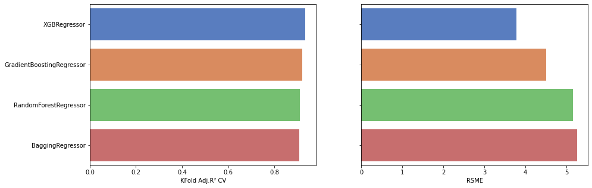

```python
kfold_df = merge_report['KFold Adj.R² CV'].apply(lambda kf: float(kf[0:6]))
merge_report['kfold_a_r2'] = kfold_df

reg_perf_df = merge_report.reset_index().rename(columns={'index':'Regressor'})
reg_perf_df.rename(columns={'index':'Regressor'}, inplace=True)
reg_perf_df.sort_values(by='kfold_a_r2', ascending=False, inplace=True)

plt.figure(figsize=(15,5))

plt.subplot(1, 2, 1)
chart = sns.barplot(reg_perf_df['kfold_a_r2'], reg_perf_df['Regressor'], palette='muted')
chart.set(ylabel='')
chart.set(xlabel='KFold Adj.R² CV')

plt.subplot(1, 2, 2)
chart = sns.barplot(reg_perf_df['RSME test'], reg_perf_df['Regressor'], palette='muted')
chart.set(yticklabels=[], ylabel='')
chart.set(xlabel='RSME')

plt.show()
```

# Conclusions

- As we are probably expected from the very beginning **XGBRegressor** gave us the **best results**. **R²** 0.9480, **Adj.R²** 0.9452, **KFold CV with Adj.R² as the scorrer** 0.9345 ± 0.02, **95% CI** [0.9234 - 0.9456] and the metric form the calass for **95% of results** is [0.9013 - 0.9589]. Also we got very low **RSME** 3.7869.
- Bagging regressors may seem to overfit on a single run, however simulation using KFold CV shows good average scores.
- Overall it was an interesting work. We did **uni/bi-variate analysis**, we had a deep go at **EDA** and **Feature Engineering** and created new features, selected features per each model, used PCA, PolynomialFeatures, scalers/transformers etc. and finally produced models which are considerably better for all basic regressors. As the final step we picked **best 4** models and performed **hyper parameters tuning** for each model.
- Further optimization is possible with **GridSearchCV** where we could tune hyper parameters that we got from **RandomizedSearchCV** even more by using a smaller steps around the values.
- In this research we decided to be conservative and used **Adj.R²** as our main validation metric. However we also collected **R²**, **KFold Adj.R² CV**, **95% CI**, **RSME** etc. to support our findings.
- One of the important features that we used is **pipelines**. They are invaluable when it comes to preventing **data leaks** and minimizing human error.
- Convinient **Summary** dataframes/sections were also provided for the ease of reading.